# Pharmacogenetics: treatment outcomes

- Show All Code
- Hide All Code
- View Source

Author

Florence Ghestem

Published

August 26, 2026

# What this document does

This is the complete analysis behind *Pharmacogenetics: treatment outcomes* from the raw extracts to every figure and table in the document.

The only thing you may need to change is `data_root` in the YAML header above, which must point at the `DATA` directory. Every path is derived from it.

## Reading this document alongside the paper

Each output is flagged:

- **Paper output**: reproduces a specific figure or table in in the overleaf document
- **Internal check**: a working output that is not in the paper, they are sanity-checks.

Code follows the paper’s vocabulary. The glossary below maps one to the other.

| Paper term | Variable in this document | Meaning |
| --- | --- | --- |
| indication group | `indication_group` | Drugs sharing an indication, grouped by ATC level |
| drug | `drug_name` | Molecule name (e.g. `atorvastatin`) |
| dispensing | `dispensings` | One delivery event of one drug to one individual |
| refill | — | A repeated dispensing of a drug the individual is already taking |
| empirical refill window | `refill_window_months` | Shortest window covering ≥ 75 % of individuals’ maximum refill intervals, capped at 6 months |
| incident user | `incident_users` | First dispensing ≥ 12 months after the database start |
| drug episode | `treatment_episodes` | Maximal run of dispensings of one drug with no gap longer than the refill window |
| episode rank | `episode_rank` | 1st / 2nd / 3rd+ episode for that individual |
| short-term outcome | `short_term_outcomes` | continued / switched / dropped within the first refill window |
| PGx predisposition | `pgx_variables` | The four ClinPGx recommendation categories, as binary per individual x drug |

## Data sources

Three sources, all read-only, none of them produced by this document:

| Source | Path under `data_root` | Used for |
| --- | --- | --- |
| CONSTANCES population questionnaire | `01-raw/…_100GOLD_01/0_DATA_POP.{txt,csv}` | Sex, birth date, eligible individuals |
| SNDS drug dispensings | `01-raw/…_100GOLD_03/{individus,med_*}.sas7bdat` | Dispensing records |
| PGx annotations | `03-ready/geno-data/` | Per individual × drug predispositions (from Marc) |

```r
# Packages

library(readr)
library(dplyr)
library(tidyr)
library(purrr)
library(stringr)
library(forcats)
library(tibble)
library(lubridate)
library(ggplot2)
library(patchwork)
library(gt)
library(survival)

# Paths. Everything hangs off the `data_root` parameter
data_root <- params[["data_root"]]
questionnaire_dir <- file.path(
  data_root, "01-raw", "Constance_Gazel_Donnees_Extract_100GOLD_01"
)
snds_dir <- file.path(
  data_root, "01-raw", "Constance_Gazel_Donnees_Extract_100GOLD_03"
)
geno_dir <- file.path(data_root, "03-ready", "geno-data")

stopifnot(
  "questionnaire extract not found: check data_root" = dir.exists(questionnaire_dir),
  "SNDS extract not found: check data_root" = dir.exists(snds_dir),
  "genotype-derived PGx directory not found: check data_root" = dir.exists(geno_dir)
)
```

# Parameters and conventions

```r
# Study window (in overleaf doc, "Cohort definition")
db_start <- as.Date("2007-01-01") # first date covered by the dispensing database
followup_end <- as.Date("2022-12-31") # end of follow-up
incident_washout_days <- 365L
# an incident user's first dispensing must fall after this much time has elapsed since
# db_start, so that people already on treatment when the
# database opens ("prevalent users") are excluded

# PGx predispositions
# Four binary variables per individual x drug, one per ClinPGx recommendation category.
# TRUE = has a PGx recommendation for the drug
pgx_variables <- c(
  "recommendation",
  "AlternateDrug",
  "DosingInformation",
  "otherGuidance"
)
pgx_labels <- c(
  recommendation = "Recommendation",
  AlternateDrug = "Alternate drug",
  DosingInformation = "Dosing information",
  otherGuidance = "Other guidance"
)

# Indication groups (in overleaf doc, Table \ref{tab:drug-and-threshold})
# Pre-specified before analysis: the six groups with enough treated individuals in the
# cohort to give the models usable power
indication_levels <- c(
  "Lipid-lowering",
  "Acid suppression",
  "Antidepressant",
  "Antiplatelet",
  "Gout",
  "Antiarrhythmic"
)

# Outcome levels
# `continued` is first because it is the reference category of the multinomial model.
status_levels <- c("continued", "switched", "dropped")

# Model fitting guards (in overleaf doc, Material and methods)
min_per_cell <- 5L # minimum individuals per PGx x outcome
min_events <- 15L # minimum individuals per outcome
```

```r
significance_colours <- c(`FALSE` = "grey60", `TRUE` = "#2166AC")
indication_colours <- c(
  "Lipid-lowering" = "#4E79A7",
  "Acid suppression" = "#F28E2B",
  "Antidepressant" = "#59A14F",
  "Antiplatelet" = "#E15759",
  "Gout" = "#B07AA1",
  "Antiarrhythmic" = "#76B7B2"
)
pgx_var_colours <- c(
  recommendation = "#0072B2",
  AlternateDrug = "#D55E00",
  DosingInformation = "#009E73",
  otherGuidance = "#CC79A7"
)

theme_pgx <- function(base_size = 11) {
  ggplot2::theme_bw(base_size = base_size) +
    ggplot2::theme(
      panel.grid.minor = ggplot2::element_blank(),
      panel.grid.major.y = ggplot2::element_blank(),
      strip.background = ggplot2::element_rect(fill = "white", colour = "white"),
      strip.placement = "outside",
      strip.text = ggplot2::element_text(face = "bold"),
      strip.text.y.left = ggplot2::element_text(angle = 0, hjust = 1),
      plot.title = ggplot2::element_text(face = "bold"),
      legend.position = "bottom"
    )
}

add_significance <- function(data, p_col = "p_adj") {
  dplyr::mutate(
    data,
    signif = !is.na(.data[[p_col]]) & .data[[p_col]] < 0.05,
    stars = dplyr::case_when(
      is.na(.data[[p_col]]) ~ "",
      .data[[p_col]] < 0.001 ~ "***",
      .data[[p_col]] < 0.01 ~ "**",
      .data[[p_col]] < 0.05 ~ "*",
      .default = ""
    ),
    estimate_ci = sprintf(
      "%.2f [%.2f; %.2f]",
      .data[["estimate"]],
      .data[["lo"]],
      .data[["hi"]]
    )
  )
}

# Benjamini-Hochberg correction applied within a subset of rows (in practice: the PGx
# coefficients only). Rows outside the subset get NA (they are not counted in the BH
# denominator, so adjusting the PGx p-values is not diluted by the age and sex
# coefficients that are in the same table
bh_within <- function(p, keep) {
  out <- rep(NA_real_, length(p))
  out[keep] <- stats::p.adjust(p[keep], method = "BH")
  out
}

fmt_p <- function(p) {
  dplyr::case_when(
    is.na(p) ~ "-",
    p < 0.001 ~ "<0.001",
    .default = sprintf("%.3f", p)
  )
}

# Forest plot
make_forest <- function(
  df,
  y_col,
  facet_row,
  facet_col,
  x_label,
  ci_label,
  title = NULL,
  subtitle = NULL,
  x_breaks = c(0.25, 0.5, 1, 2, 4),
  soft_lines = c(0.5, 2),
  order_col = NULL,
  colour_col = NULL
) {
  df <- df |>
    add_significance("p_adj") |>
    dplyr::arrange(
      !!!rlang::syms(c(facet_row, facet_col, order_col)),
      dplyr::desc(.data[["estimate"]])
    ) |>
    dplyr::mutate(y_ordered = forcats::fct_inorder(as.character(.data[[y_col]])))

  facet_spec <- ggplot2::facet_grid(
    stats::reformulate(facet_col, facet_row),
    scales = "free_y",
    space = "free_y",
    switch = "y"
  )

  p_ci <- ggplot2::ggplot(df, ggplot2::aes(x = 1, y = .data[["y_ordered"]])) +
    ggplot2::geom_text(
      ggplot2::aes(label = .data[["estimate_ci"]]),
      size = 3,
      hjust = 0.5
    ) +
    facet_spec +
    ggplot2::labs(x = ci_label, y = NULL) +
    theme_pgx() +
    ggplot2::theme(
      panel.grid = ggplot2::element_blank(),
      panel.border = ggplot2::element_blank(),
      axis.text.x = ggplot2::element_blank(),
      axis.ticks.x = ggplot2::element_blank(),
      strip.text.x = ggplot2::element_text(colour = "white"),
      legend.position = "bottom"
    )

  p_forest <- ggplot2::ggplot(
    df,
    ggplot2::aes(x = .data[["estimate"]], y = .data[["y_ordered"]])
  ) +
    ggplot2::geom_vline(xintercept = 1, linewidth = 0.4, colour = "black") +
    ggplot2::geom_vline(
      xintercept = soft_lines,
      linetype = "dashed",
      colour = "grey60",
      linewidth = 0.3
    ) +
    ggplot2::geom_pointrange(
      ggplot2::aes(
        xmin = .data[["lo"]],
        xmax = .data[["hi"]],
        colour = .data[["signif"]]
      ),
      linewidth = 0.5,
      size = 0.4
    ) +
    ggplot2::geom_text(
      ggplot2::aes(x = .data[["hi"]], label = .data[["stars"]]),
      hjust = -0.3,
      vjust = 0.75,
      size = 4,
      colour = "black"
    ) +
    ggplot2::scale_x_continuous(
      trans = "log",
      breaks = x_breaks,
      labels = as.character(x_breaks)
    ) +
    ggplot2::scale_colour_manual(
      values = significance_colours,
      labels = c(`FALSE` = "Not significant", `TRUE` = "Significant (BH)"),
      name = NULL,
      drop = FALSE
    ) +
    facet_spec +
    ggplot2::labs(x = x_label, y = NULL) +
    theme_pgx() +
    ggplot2::theme(
      strip.text.y.left = ggplot2::element_blank(),
      axis.text.y = ggplot2::element_blank(),
      axis.ticks.y = ggplot2::element_blank()
    )

  (p_ci + p_forest + patchwork::plot_layout(widths = c(2.2, 3))) +
    patchwork::plot_annotation(
      title = title,
      subtitle = subtitle,
      caption = "* p < 0.05; ** p < 0.01; *** p < 0.001 (BH-adjusted). Colour = significant after BH."
    )
}

# Result table
make_result_gt <- function(
  df,
  group_cols,
  extra_cols,
  estimate_label,
  title,
  subtitle
) {
  df |>
    dplyr::mutate(
      p_raw = fmt_p(.data[["p_value"]]),
      p_adj_fmt = fmt_p(.data[["p_adj"]])
    ) |>
    dplyr::select(dplyr::all_of(c(
      group_cols,
      extra_cols,
      "estimate_ci",
      "p_raw",
      "p_adj_fmt"
    ))) |>
    gt::gt(groupname_col = group_cols) |>
    gt::cols_label(
      estimate_ci = estimate_label,
      p_raw = "p",
      p_adj_fmt = "p (BH)"
    ) |>
    gt::tab_header(title = title, subtitle = subtitle) |>
    gt::tab_style(
      style = gt::cell_text(weight = "bold"),
      locations = gt::cells_row_groups()
    ) |>
    gt::tab_options(table.font.size = 10)
}
```

# Data preparation

The analysis needs exactly two tables, and this section builds both in memory:

- `demographics`: one row per individual: sex and birth date;
- `dispensings`: one row per individual x drug x month

## Population questionnaire: demographics

```r
population_dataset <- "0_DATA_POP"

# The dictionary csv carries a 4-line header and a 2-line footer around the actual table
population_dictionary <- file.path(
  questionnaire_dir, paste0(population_dataset, ".csv")
) |>
  readLines(encoding = "ISO-8859-1") |>
  utils::tail(-4) |>
  utils::head(-2) |>
  paste(collapse = "\n") |>
  readr::read_delim(
    delim = ";",
    col_names = c("rank", "colname", "type", "precision", "label", "legend"),
    col_types = "icccc",
    locale = readr::locale(decimal_mark = ".", encoding = "ISO-8859-1")
  ) |>
  dplyr::mutate(
    readr_type = dplyr::case_when(
      type %in% "Texte (char, nchar, nvarchar ou varchar)" ~ "c",
      type %in% "Numérique entier court (smallint entre -32768 et +32767)" |
        type %in% "Numérique entier long (integer entre -2M et +2M)" |
        type %in% "Numérique entier très long (bigint)" ~ "i",
      type %in% "Numérique décimale (decimal)" ~ "d",
      type %in% "Time" ~ "c",
      type %in% "Date (date, datetime, ...)" & precision %in% "ddmmyy10." ~ "c",
      TRUE ~ "?"
    )
  ) |>
  dplyr::mutate(
    # The dictionary spells some column names with a trailing "_N" where the data file
    # has "_n"
    colname = gsub("_N$", "_n", colname),
    field = tolower(colname)
  )
```

```r
# Split one legend string into the code -> label mapping it describes
parse_legend <- function(legend) {
  modalities <- unlist(strsplit(legend, '\" '))
  labels <- gsub(
    '\\"', "",
    gsub("^[0-9]+=|^ [0-9]+=|^[0-9]+ =", "", modalities)
  )
  tibble::tibble(
    code = as.numeric(gsub("=.*", "", modalities)),
    # The extract encodes apostrophes as Windows-1252 0x92; normalise them to ASCII,
    # and upper-case the initial letter so labels read consistently
    label = stringr::str_replace_all(gsub("\u0092", "'", labels), "^.", toupper)
  )
}

# Turn a column of integer codes back into its labels, using the dictionary
recode_from_legend <- function(x, field_name, dictionary = population_dictionary) {
  legend <- dictionary[["legend"]][dictionary[["field"]] == field_name]
  stopifnot(
    "field is not in the data dictionary" = length(legend) == 1L,
    "field has no legend in the data dictionary" = !is.na(legend) && legend != " ",
    "field is not a coded numeric column" = is.numeric(x)
  )
  modalities <- parse_legend(legend)
  as.character(
    factor(x, levels = modalities[["code"]], labels = modalities[["label"]])
  )
}
```

```r
# Date columns are declared in the dictionary with two different precisions and must be
# parsed accordingly
dates_mm_yyyy <- population_dictionary |>
  dplyr::filter(
    type %in% "Texte (char, nchar, nvarchar ou varchar)",
    precision %in% "mm/yyyy"
  ) |>
  dplyr::pull("colname") |>
  unique()

dates_dd_mm_yyyy <- population_dictionary |>
  dplyr::filter(
    type %in% "Date (date, datetime, ...)",
    precision %in% "ddmmyy10."
  ) |>
  dplyr::pull("colname") |>
  unique()

population <- readr::read_delim(
  file.path(questionnaire_dir, paste0(population_dataset, ".txt")),
  delim = ";",
  locale = readr::locale(encoding = "ISO-8859-1", decimal_mark = "."),
  col_types = setNames(
    as.list(population_dictionary[["readr_type"]]),
    population_dictionary[["colname"]]
  )
) |>
  dplyr::mutate(dplyr::across(
    dplyr::any_of(dates_mm_yyyy), ~ readr::parse_date(.x, format = "%m/%Y")
  )) |>
  dplyr::mutate(dplyr::across(
    dplyr::any_of(dates_dd_mm_yyyy), ~ readr::parse_date(.x, format = "%d/%m/%Y")
  )) |>
  dplyr::rename_all(tolower)

# Some participants asked for their consent to be withdrawn after inclusion. They are
# removed everywhere, including from the list of individuals whose dispensings we read
consent_withdrawn <- population |>
  dplyr::filter(!is.na(fm_per_decon1) | !is.na(fm_per_decon2)) |>
  dplyr::distinct() |>
  dplyr::pull("proj_isp")

demographics <- population |>
  dplyr::filter(!proj_isp %in% consent_withdrawn) |>
  dplyr::transmute(
    individual_id = .data[["proj_isp"]],
    # Male is the reference level, so it comes first.
    sex = factor(
      recode_from_legend(.data[["fm_sexe"]], "fm_sexe"),
      levels = c("Masculin", "Féminin"),
      labels = c("male", "female")
    ),
    birth_date = as.Date(.data[["fm_per_naissance"]], format = "%Y-%m-%d")
  )

# Population whose dispensings we go and fetch
inclusion_ids <- unique(demographics[["individual_id"]])
```

## SNDS extract: dispensings

The SNDS extract holds one SAS file per year of dispensing records. We keep only individuals who are both consenting CONSTANCES participants and flagged as extractable in the SNDS linkage, and only dispensings of drugs belonging to the six indication groups. Filtering inside the per-file read rather than after concatenating keeps memory flat, and is equivalent because both conditions are row-wise.

```r
# PGx annotations, produced upstream from imputed whole-genome data: PyPGx infers
# categorical pharmacogene expression levels, which are then mapped onto CPIC and DPWG
# gene-drug recommendations as curated in ClinPGx. Supplied as one data frame per drug.
load(file.path(geno_dir, "PGx_reco_per_ind_per_drug.Rdata")) # provides `drug_list`

pgx_predispositions <- purrr::imap(
  drug_list,
  \(df, drug) {
    df |>
      dplyr::transmute(
        individual_id = .data[["IID"]],
        drug_name = drug,
        dplyr::across(dplyr::any_of(pgx_variables))
      )
  }
) |>
  purrr::list_rbind() |>
  dplyr::distinct()
```

```r
# Drug -> ATC code -> indication group. Statins are collapsed from their ATC level-4
# codes (C10AA, C10BA, ...) to C10, because we treat lipid-lowering as one group
atc_map <- readr::read_tsv(
  file.path(geno_dir, "drugs_with_PGx_reco.tsv"),
  col_types = readr::cols(.default = "c")
) |>
  tidyr::separate_longer_delim("atc", delim = ",") |>
  dplyr::mutate(
    atc = stringr::str_trim(.data[["atc"]]),
    atc3 = stringr::str_sub(.data[["atc"]], 1L, 4L),
    atc3 = dplyr::if_else(
      stringr::str_starts(.data[["atc3"]], "C10"), "C10", .data[["atc3"]]
    ),
    indication_group = dplyr::case_when(
      atc3 == "C10" ~ "Lipid-lowering",
      atc3 == "A02B" ~ "Acid suppression",
      atc3 == "N06A" ~ "Antidepressant",
      atc3 == "B01A" ~ "Antiplatelet",
      atc3 == "M04A" ~ "Gout",
      atc3 == "C01B" ~ "Antiarrhythmic",
      .default = NA_character_
    )
  ) |>
  dplyr::rename(drug_name = "name") |>
  # Drops drugs outside the six pre-specified indication groups
  dplyr::filter(!is.na(.data[["indication_group"]]))

drug_indication_map <- dplyr::distinct(atc_map, drug_name, atc3, indication_group)
```

```r
# Individuals eligible for SNDS linkage: consenting, matched on their social security
# number, and present in the beneficiary reference table
eligible_ids <- haven::read_sas(file.path(snds_dir, "individus.sas7bdat")) |>
  dplyr::filter(
    extractible == 1,
    consentement_snds == 1,
    individu_NIR == 1,
    present_IR_BEN_R == 1,
    ISP %in% inclusion_ids
  ) |>
  dplyr::pull("ISP")

# Only dispensings whose ATC7 code starts with one of the six group prefixes
target_atc3 <- unique(atc_map[["atc3"]])
atc3_regex <- paste0("^(", paste(target_atc3, collapse = "|"), ")")

dispensing_files <- list.files(snds_dir, pattern = "^med.*\\.sas7bdat$")

dispensings <- purrr::map(
  file.path(snds_dir, dispensing_files),
  \(path) {
    path |>
      haven::read_sas() |>
      dplyr::filter(
        ISP %in% eligible_ids,
        stringr::str_detect(.data[["atc7"]], atc3_regex)
      ) |>
      dplyr::select(dplyr::all_of(c(
        "ISP", "atc7", "box_count", "date_mois", "date_annee"
      ))) |>
      # SAS columns arrive carrying value labels and format attributes, I strip them, so
      # that `box_count` is a plain numeric
      haven::zap_labels() |>
      haven::zap_formats()
  }
) |>
  purrr::list_rbind() |>
  dplyr::arrange(.data[["date_annee"]]) |>
  dplyr::left_join(atc_map, by = c("atc7" = "atc")) |>
  dplyr::rename(individual_id = "ISP") |>
  dplyr::mutate(
    # Dispensings are dated to the month; day 1 stands in for the whole month
    date = lubridate::make_date(.data[["date_annee"]], .data[["date_mois"]], 1L),
    atc3 = stringr::str_sub(.data[["atc7"]], 1L, 4L),
    atc3 = dplyr::if_else(
      stringr::str_starts(.data[["atc7"]], "C10"), "C10", .data[["atc3"]]
    ),
    # Drugs without a PGx annotation keep their ATC7 code as their name, so that they
    # still count as within-group alternatives when detecting switches
    drug_name = dplyr::coalesce(.data[["drug_name"]], .data[["atc7"]])
  ) |>
  dplyr::distinct(individual_id, drug_name, atc3, date, box_count)
```

# Cohort

The study cohort is the set of individual x drug pairs that have a PGx annotation, a dispensing record, and demographics, restricted to incident users: those whose first dispensing anywhere in that indication group falls at least 12 months after the database opens, so that people already on treatment in 2007 are excluded. One row per individual x drug x indication group.

```r
# Each filter is kept as its own named object
dispensings_pgx_drugs <- dplyr::semi_join(dispensings, atc_map, by = "drug_name")

first_dispensing_per_drug <- dispensings_pgx_drugs |>
  dplyr::group_by(individual_id, drug_name, atc3) |>
  dplyr::summarise(first_dispensing = min(date), .groups = "drop")

# Incidence is judged at the level of the INDICATION GROUP, not the individual drug:
# someone dispensed omeprazole since 2005 who moves to pantoprazole in 2015 is a prevalent
# user of acid suppression, even though pantoprazole itself is new to them. The first
# dispensing is taken over every drug in the group, PGx-annotated or not, because a
# non-annotated alternative is still treatment for that indication.
first_dispensing_per_group <- dispensings |>
  dplyr::group_by(individual_id, atc3) |>
  dplyr::summarise(group_first_dispensing = min(date), .groups = "drop")

incident_users <- first_dispensing_per_drug |>
  dplyr::inner_join(first_dispensing_per_group, by = c("individual_id", "atc3")) |>
  dplyr::filter(
    .data[["group_first_dispensing"]] >= db_start + incident_washout_days
  ) |>
  dplyr::select(-"group_first_dispensing")

incident_with_demographics <- dplyr::inner_join(
  incident_users, demographics, by = "individual_id"
)

cohort <- incident_with_demographics |>
  dplyr::inner_join(pgx_predispositions, by = c("individual_id", "drug_name")) |>
  dplyr::inner_join(drug_indication_map, by = c("drug_name", "atc3")) |>
  dplyr::mutate(
    age_first = as.numeric(.data[["first_dispensing"]] - .data[["birth_date"]]) / 365.25
  )
```

**Paper output**: Table `\ref{tab:flowchart}`

```r
flowchart_gt <- tibble::tibble(
  step = factor(
    c(
      "All deliveries",
      "PGx drugs only",
      "Incident users",
      "+ demographics",
      "+ PGx covariates"
    ),
    levels = c(
      "All deliveries",
      "PGx drugs only",
      "Incident users",
      "+ demographics",
      "+ PGx covariates"
    )
  ),
  n_individuals = c(
    dplyr::n_distinct(dispensings[["individual_id"]]),
    dplyr::n_distinct(dispensings_pgx_drugs[["individual_id"]]),
    dplyr::n_distinct(incident_users[["individual_id"]]),
    dplyr::n_distinct(incident_with_demographics[["individual_id"]]),
    dplyr::n_distinct(cohort[["individual_id"]])
  ),
  n_episodes = c(
    nrow(dplyr::distinct(dispensings, individual_id, drug_name)),
    nrow(dplyr::distinct(dispensings_pgx_drugs, individual_id, drug_name)),
    nrow(incident_users),
    nrow(incident_with_demographics),
    nrow(cohort)
  )
) |>
  gt::gt() |>
  gt::cols_label(
    step = "Step",
    n_individuals = "N individuals",
    n_episodes = "N episodes (individual x drug)"
  ) |>
  gt::tab_header(title = "Cohort flowchart") |>
  gt::tab_options(table.font.size = 11)

flowchart_gt
```

Cohort flowchart

| Step | N individuals | N episodes (individual x drug) |
| --- | --- | --- |
| All deliveries | 8393 | 35669 |
| PGx drugs only | 7465 | 17513 |
| Incident users | 6310 | 12000 |
| + demographics | 6310 | 12000 |
| + PGx covariates | 6189 | 11764 |

**Paper output**: cohort size per indication group

```r
cohort_size_gt <- cohort |>
  dplyr::mutate(
    indication_group = factor(.data[["indication_group"]], levels = indication_levels)
  ) |>
  dplyr::group_by(indication_group) |>
  dplyr::summarise(
    n_individuals = dplyr::n_distinct(.data[["individual_id"]]),
    n_drugs = dplyr::n_distinct(.data[["drug_name"]]),
    n_pairs = dplyr::n(),
    .groups = "drop"
  ) |>
  dplyr::arrange(.data[["indication_group"]]) |>
  gt::gt() |>
  gt::cols_label(
    indication_group = "Indication group",
    n_individuals = "N individuals",
    n_drugs = "N drugs",
    n_pairs = "N individual x drug"
  ) |>
  gt::tab_header(
    title = "Cohort size per indication group",
    subtitle = sprintf(
      "%s distinct individuals in the cohort overall; the column below does not sum to that total, because one individual can be treated in several indication groups",
      dplyr::n_distinct(cohort[["individual_id"]])
    )
  ) |>
  gt::tab_options(table.font.size = 11)

cohort_size_gt
```

Cohort size per indication group

6189 distinct individuals in the cohort overall; the column below does not sum to that total, because one individual can be treated in several indication groups

| Indication group | N individuals | N drugs | N individual x drug |
| --- | --- | --- | --- |
| Lipid-lowering | 1310 | 5 | 1663 |
| Acid suppression | 4990 | 3 | 7349 |
| Antidepressant | 1602 | 12 | 2205 |
| Antiplatelet | 188 | 3 | 191 |
| Gout | 152 | 1 | 152 |
| Antiarrhythmic | 198 | 2 | 204 |

**LaTeX source for overleaf document**

````r
cat("```latex\n", gt::as_latex(cohort_size_gt), "\n```\n", sept="")
````

```latex
 \begin{table}
\caption*{
{\large Cohort size per indication group} \\
{\small 6189 distinct individuals in the cohort overall; the column below does not sum to that total, because one individual can be treated in several indication groups}
}
\fontsize{8.2pt}{9.9pt}\selectfont
\begin{tabular*}{\linewidth}{@{\extracolsep{\fill}}crrr}
\toprule
Indication group & N individuals & N drugs & N individual x drug \\
\midrule\addlinespace[2.5pt]
Lipid-lowering & 1310 & 5 & 1663 \\
Acid suppression & 4990 & 3 & 7349 \\
Antidepressant & 1602 & 12 & 2205 \\
Antiplatelet & 188 & 3 & 191 \\
Gout & 152 & 1 & 152 \\
Antiarrhythmic & 198 & 2 & 204 \\
\bottomrule
\end{tabular*}
\end{table}
```

**LaTeX source for overleaf document**

````r
cat("```latex\n", gt::as_latex(flowchart_gt), "\n```\n", sept="")
````

```latex
 \begin{table}
\caption*{
{\large Cohort flowchart}
}
\fontsize{8.2pt}{9.9pt}\selectfont
\begin{tabular*}{\linewidth}{@{\extracolsep{\fill}}crr}
\toprule
Step & N individuals & N episodes (individual x drug) \\
\midrule\addlinespace[2.5pt]
All deliveries & 8393 & 35669 \\
PGx drugs only & 7465 & 17513 \\
Incident users & 6310 & 12000 \\
+ demographics & 6310 & 12000 \\
+ PGx covariates & 6189 & 11764 \\
\bottomrule
\end{tabular*}
\end{table}
```

# Empirical refill window

The expected refill window is how long a gap between two dispensings still counts as continuous treatment. Rather than impose one threshold, we read it off the data per drug: take each individual’s largest interval between consecutive dispensings during their first year on the drug, then choose the smallest whole number of months covering at least 75 % of individuals. The result is capped at 6 months, beyond which “still on treatment” stops being credible.

This window is used twice: as the observation period for short-term outcomes, and as the gap that separates one treatment episode from the next.

```r
# Per individual x drug: the largest gap between two consecutive dispensings in the first
# year. Individuals with a single dispensing in that year contribute no interval and are
# excluded. Computed once and used both to pick the window and to draw the curve below.
max_refill_interval <- function(dispensings) {
  dispensings |>
    dplyr::group_by(individual_id, drug_name) |>
    dplyr::summarise(
      first_dispensing = min(date),
      n_dispensings = dplyr::n(),
      .groups = "drop"
    ) |>
    dplyr::filter(.data[["n_dispensings"]] >= 2) |>
    dplyr::inner_join(
      dispensings,
      by = c("individual_id", "drug_name"),
      relationship = "one-to-many"
    ) |>
    dplyr::filter(
      date >= .data[["first_dispensing"]],
      date <= .data[["first_dispensing"]] + years(1L)
    ) |>
    dplyr::arrange(individual_id, drug_name, date) |>
    dplyr::group_by(individual_id, drug_name) |>
    dplyr::summarise(
      max_int = if (dplyr::n() > 1L) {
        max(as.numeric(lubridate::interval(lag(date), date) / months(1)), na.rm = TRUE)
      } else {
        NA_integer_
      },
      .groups = "drop"
    ) |>
    dplyr::filter(!is.na(.data[["max_int"]]))
}

compute_refill_window <- function(
  dispensings,
  pct = 0.75,
  candidates = seq(1L, 12L, 1L)
) {
  dispensings |>
    max_refill_interval() |>
    dplyr::group_by(drug_name) |>
    dplyr::summarise(
      refill_window_months = candidates[which(
        purrr::map_dbl(candidates, \(g) mean(.data[["max_int"]] <= g)) >= pct
      )[1]],
      .groups = "drop"
    ) |>
    dplyr::mutate(
      # No candidate reaches 75%: fall back to the widest, then apply the 6-month cap.
      refill_window_months = dplyr::if_else(
        is.na(.data[["refill_window_months"]]),
        max(candidates),
        .data[["refill_window_months"]]
      ),
      refill_window_months = pmin(.data[["refill_window_months"]], 6L)
    )
}

cohort_dispensings <- dplyr::semi_join(
  dispensings, cohort, by = c("individual_id", "drug_name")
)

refill_windows <- compute_refill_window(cohort_dispensings) |>
  dplyr::inner_join(drug_indication_map, by = "drug_name") |>
  dplyr::mutate(
    indication_group = factor(.data[["indication_group"]], levels = indication_levels)
  ) |>
  dplyr::arrange(.data[["indication_group"]], drug_name)
```

**Paper output**: Table `\ref{tab:drug-and-threshold}`

```r
refill_windows_gt <- refill_windows |>
  dplyr::select(indication_group, drug_name, atc3, refill_window_months) |>
  gt::gt(groupname_col = "indication_group") |>
  gt::cols_label(
    drug_name = "Drug",
    atc3 = "ATC3",
    refill_window_months = "Refill window (months)"
  ) |>
  gt::tab_header(
    title = "Empirical refill window per drug",
    subtitle = "Smallest window covering ≥ 75% of individuals' maximum year-1 refill intervals (capped at 6 months)"
  ) |>
  gt::tab_style(
    style = gt::cell_text(weight = "bold"),
    locations = gt::cells_row_groups()
  ) |>
  gt::tab_options(table.font.size = 11)

refill_windows_gt
```

Empirical refill window per drug

Smallest window covering ≥ 75% of individuals' maximum year-1 refill intervals (capped at 6 months)

| Drug | ATC3 | Refill window (months) |
| --- | --- | --- |
| Lipid-lowering |  |  |
| atorvastatin | C10 | 4 |
| fluvastatin | C10 | 5 |
| pravastatin | C10 | 3 |
| rosuvastatin | C10 | 4 |
| simvastatin | C10 | 4 |
| Acid suppression |  |  |
| lansoprazole | A02B | 6 |
| omeprazole | A02B | 6 |
| pantoprazole | A02B | 6 |
| Antidepressant |  |  |
| amitriptyline | N06A | 6 |
| citalopram | N06A | 2 |
| clomipramine | N06A | 3 |
| doxepin | N06A | 4 |
| escitalopram | N06A | 2 |
| fluvoxamine | N06A | 3 |
| imipramine | N06A | 2 |
| paroxetine | N06A | 2 |
| sertraline | N06A | 2 |
| trimipramine | N06A | 3 |
| venlafaxine | N06A | 2 |
| vortioxetine | N06A | 2 |
| Antiplatelet |  |  |
| acenocoumarol | B01A | 3 |
| clopidogrel | B01A | 2 |
| warfarin | B01A | 2 |
| Gout |  |  |
| allopurinol | M04A | 2 |
| Antiarrhythmic |  |  |
| flecainide | C01B | 2 |
| propafenone | C01B | 3 |

**LaTeX source for overleaf document**

````r
cat("```latex\n", gt::as_latex(refill_windows_gt), "\n```\n", sep="")
````

```latex
\begin{table}
\caption*{
{\large Empirical refill window per drug} \\
{\small Smallest window covering ≥ 75\% of individuals' maximum year-1 refill intervals (capped at 6 months)}
}
\fontsize{8.2pt}{9.9pt}\selectfont
\begin{tabular*}{\linewidth}{@{\extracolsep{\fill}}llr}
\toprule
Drug & ATC3 & Refill window (months) \\
\midrule\addlinespace[2.5pt]
\multicolumn{3}{l}{{\bfseries Lipid-lowering}} \\[2.5pt]
\midrule\addlinespace[2.5pt]
atorvastatin & C10 & 4 \\
fluvastatin & C10 & 5 \\
pravastatin & C10 & 3 \\
rosuvastatin & C10 & 4 \\
simvastatin & C10 & 4 \\
\midrule\addlinespace[2.5pt]
\multicolumn{3}{l}{{\bfseries Acid suppression}} \\[2.5pt]
\midrule\addlinespace[2.5pt]
lansoprazole & A02B & 6 \\
omeprazole & A02B & 6 \\
pantoprazole & A02B & 6 \\
\midrule\addlinespace[2.5pt]
\multicolumn{3}{l}{{\bfseries Antidepressant}} \\[2.5pt]
\midrule\addlinespace[2.5pt]
amitriptyline & N06A & 6 \\
citalopram & N06A & 2 \\
clomipramine & N06A & 3 \\
doxepin & N06A & 4 \\
escitalopram & N06A & 2 \\
fluvoxamine & N06A & 3 \\
imipramine & N06A & 2 \\
paroxetine & N06A & 2 \\
sertraline & N06A & 2 \\
trimipramine & N06A & 3 \\
venlafaxine & N06A & 2 \\
vortioxetine & N06A & 2 \\
\midrule\addlinespace[2.5pt]
\multicolumn{3}{l}{{\bfseries Antiplatelet}} \\[2.5pt]
\midrule\addlinespace[2.5pt]
acenocoumarol & B01A & 3 \\
clopidogrel & B01A & 2 \\
warfarin & B01A & 2 \\
\midrule\addlinespace[2.5pt]
\multicolumn{3}{l}{{\bfseries Gout}} \\[2.5pt]
\midrule\addlinespace[2.5pt]
allopurinol & M04A & 2 \\
\midrule\addlinespace[2.5pt]
\multicolumn{3}{l}{{\bfseries Antiarrhythmic}} \\[2.5pt]
\midrule\addlinespace[2.5pt]
flecainide & C01B & 2 \\
propafenone & C01B & 3 \\
\bottomrule
\end{tabular*}
\end{table}
```

**Paper output**: Figure `\ref{fig:threshold}` (`figures/window-supp-1.png` to `-6.png`, one per indication group)

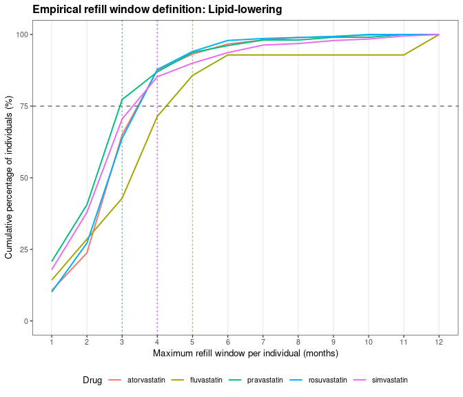

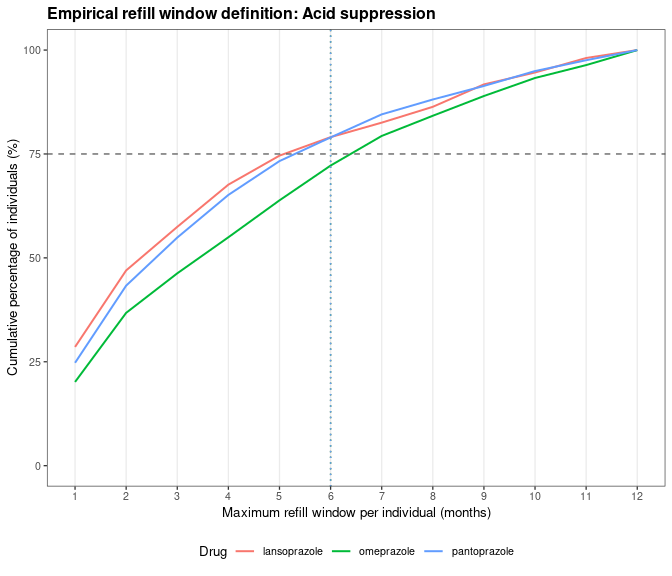

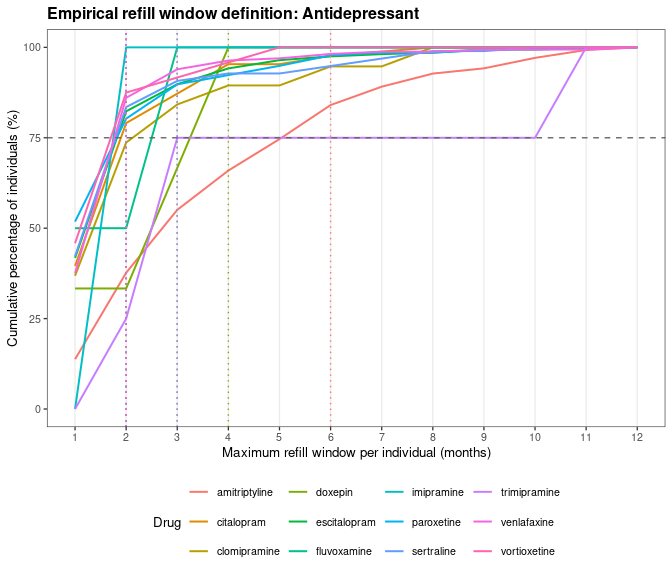

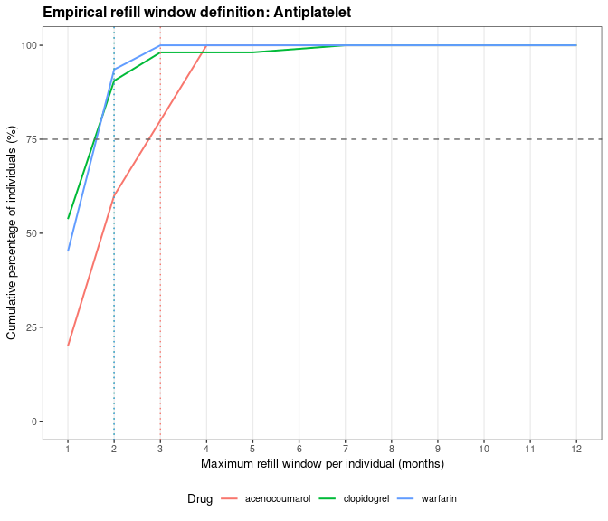

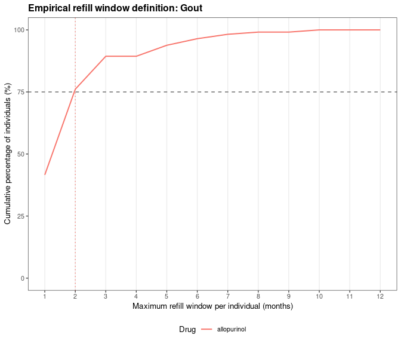

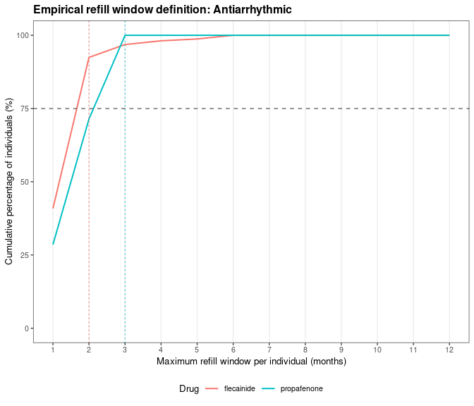

```r
# Cumulative share of individuals whose maximum refill interval falls at or below each
# candidate window. The horizontal line is the 75% criterion; the dotted vertical lines
# are the windows actually selected.
refill_capture_curve <- cohort_dispensings |>
  max_refill_interval() |>
  tidyr::crossing(gap = seq(1L, 12L, 1L)) |>
  dplyr::group_by(drug_name, gap) |>
  dplyr::summarise(
    pct = 100 * mean(.data[["max_int"]] <= .data[["gap"]]),
    .groups = "drop"
  ) |>
  dplyr::inner_join(drug_indication_map, by = "drug_name")

window_lookup <- dplyr::select(
  refill_windows, drug_name, refill_window_months, indication_group
)

purrr::walk(indication_levels, \(group) {
  curve <- dplyr::filter(refill_capture_curve, indication_group == group)
  if (nrow(curve) == 0L) {
    return(invisible(NULL))
  }
  windows <- dplyr::filter(window_lookup, indication_group == group)
  p <- ggplot2::ggplot(
    curve,
    ggplot2::aes(
      x = .data[["gap"]], y = .data[["pct"]], colour = .data[["drug_name"]]
    )
  ) +
    ggplot2::geom_line(linewidth = 0.7) +
    ggplot2::geom_hline(yintercept = 75, linetype = "dashed", colour = "grey40") +
    ggplot2::geom_vline(
      data = windows,
      mapping = ggplot2::aes(
        xintercept = .data[["refill_window_months"]], colour = .data[["drug_name"]]
      ),
      linetype = "dotted",
      linewidth = 0.5,
      show.legend = FALSE
    ) +
    ggplot2::scale_x_continuous(breaks = seq(0L, 12L, 1L)) +
    ggplot2::scale_y_continuous(limits = c(0, 100)) +
    ggplot2::labs(
      x = "Maximum refill window per individual (months)",
      y = "Cumulative percentage of individuals (%)",
      colour = "Drug",
      title = sprintf("Empirical refill window definition: %s", group)
    ) +
    theme_pgx(base_size = 10)
  print(p)
})
```

# Building the outcomes

Two outcome tables are built from the same dispensings, answering two different questions.

- **Short term**: what happens inside the first refill window after someone starts a drug, the period when a clinician is still assessing whether it works and is tolerated.
- **Long term**: what happens across the whole follow-up, where treatment is adapted for cumulative side effects or loss of efficacy.

## Long-term: treatment episodes

An episode is a maximal run of dispensings of one drug in which no two consecutive dispensings are further apart than that drug’s refill window; a longer gap starts a new episode. Each episode ends in one of three ways, and the earliest wins:

- **switched** (`event = 1`): a different drug in the same indication group is dispensed within one window of the episode’s last dispensing;
- **dropped** (`event = 2`): nothing more is dispensed, and there was enough time left before the end of follow-up to have observed a refill;
- **continued** (`event = 0`): still on treatment when follow-up ends, i.e. censored.

```r
# Cut an individual's dispensings of one drug into episodes, then number the episodes
# chronologically across all of that individual's drugs
segment_into_episodes <- function(dispensings, refill_window_months = 12L) {
  dispensings |>
    dplyr::arrange(individual_id, drug_name, date) |>
    dplyr::group_by(individual_id, drug_name) |>
    dplyr::mutate(
      windows = ifelse(
        !is.na(lag(date)),
        as.numeric(lubridate::interval(dplyr::lag(date), date) / months(1)),
        NA
      ),
      # The first dispensing has no predecessor, so it always opens an episode
      new_episode = (is.na(windows) | windows > refill_window_months),
      episode_within_drug = cumsum(.data[["new_episode"]])
    ) |>
    dplyr::ungroup() |>
    dplyr::group_by(individual_id, drug_name, episode_within_drug) |>
    dplyr::mutate(episode_start = min(date)) |>
    dplyr::ungroup() |>
    dplyr::arrange(individual_id, episode_start) |>
    dplyr::group_by(individual_id) |>
    dplyr::mutate(episode_id = dplyr::dense_rank(.data[["episode_start"]])) |>
    dplyr::ungroup() |>
    dplyr::select(individual_id, drug_name, date, episode_id)
}

build_drug_episodes <- function(
  drug_name,
  atc3,
  group_dispensings,
  refill_window_months,
  followup_end,
  cohort
) {
  cohort_ids <- cohort |>
    dplyr::filter(drug_name == .env[["drug_name"]]) |>
    dplyr::pull(individual_id)
  drug_dispensings <- dplyr::filter(
    group_dispensings,
    drug_name == .env[["drug_name"]],
    individual_id %in% cohort_ids
  )
  if (nrow(drug_dispensings) == 0L) {
    return(NULL)
  }
  segmented <- segment_into_episodes(drug_dispensings, refill_window_months)
  trajectories <- segmented |>
    dplyr::group_by(individual_id, drug_name, episode_id) |>
    dplyr::summarise(
      episode_start = min(date),
      episode_end_dispensing = max(date),
      .groups = "drop"
    ) |>
    dplyr::mutate(
      # TRUE when follow-up ends too soon after the last dispensing for a missing refill
      # to be interpretable: the episode is censored, not dropped
      ends_at_cutoff = lubridate::interval(
        .data[["episode_end_dispensing"]], followup_end
      ) / months(1) < refill_window_months
    )

  # A switch is any dispensing of a DIFFERENT drug in the same indication group, within
  # one window of the last dispensing of this episode
  other_dispensings <- dplyr::filter(
    group_dispensings,
    individual_id %in% cohort_ids,
    drug_name != .env[["drug_name"]]
  )
  switch_info <- dplyr::inner_join(
    x = dplyr::filter(trajectories, !.data[["ends_at_cutoff"]]),
    y = dplyr::rename(
      other_dispensings, drug_name_other = drug_name, date_other = date
    ),
    by = "individual_id",
    relationship = "many-to-many"
  ) |>
    dplyr::filter(
      .data[["date_other"]] > .data[["episode_end_dispensing"]],
      .data[["date_other"]] <=
        (.data[["episode_end_dispensing"]] %m+% months(refill_window_months))
    ) |>
    dplyr::group_by(individual_id, drug_name, episode_id) |>
    dplyr::summarise(t_switch = min(.data[["date_other"]]), .groups = "drop")

  # Where this drug sits in the individual's sequence of drugs within the group
  drug_seq_rank <- group_dispensings |>
    dplyr::filter(individual_id %in% cohort_ids) |>
    dplyr::group_by(individual_id, atc3, drug_name) |>
    dplyr::summarise(drug_first = min(date), .groups = "drop") |>
    dplyr::group_by(individual_id) |>
    dplyr::arrange(.data[["drug_first"]], .by_group = TRUE) |>
    dplyr::mutate(rank_in_sequence = dplyr::row_number()) |>
    dplyr::ungroup() |>
    dplyr::filter(drug_name == .env[["drug_name"]]) |>
    dplyr::select(individual_id, rank_in_sequence)

  trajectories |>
    dplyr::left_join(switch_info, by = c("individual_id", "drug_name", "episode_id")) |>
    dplyr::mutate(
      event = dplyr::case_when(
        !is.na(.data[["t_switch"]]) ~ 1L, # switched
        !.data[["ends_at_cutoff"]] ~ 2L, # dropped
        .default = 0L # continued (censored at end of follow-up)
      ),
      time = dplyr::case_when(
        .data[["event"]] == 1L ~ as.integer(
          lubridate::interval(.data[["episode_start"]], .data[["t_switch"]]) / months(1)
        ),
        .data[["event"]] == 2L ~ as.integer(
          lubridate::interval(
            .data[["episode_start"]], .data[["episode_end_dispensing"]]
          ) / months(1)
        ),
        .data[["event"]] == 0L ~ as.integer(
          lubridate::interval(.data[["episode_start"]], followup_end) / months(1)
        )
      ) + 1,
      # The + 1 above keeps single-dispensing episodes in the analysis: without it their
      # follow-up time is zero and Cox drops them. It treats one dispensing as at least
      # one month of exposure, which is a broad approximation
      drug_name = .env[["drug_name"]],
      atc3 = .env[["atc3"]]
    ) |>
    dplyr::left_join(drug_seq_rank, by = "individual_id") |>
    dplyr::mutate(
      episode_rank = factor(
        dplyr::case_when(
          .data[["rank_in_sequence"]] == 1L ~ "1st",
          .data[["rank_in_sequence"]] == 2L ~ "2nd",
          .default = "3rd+"
        ),
        levels = c("1st", "2nd", "3rd+")
      )
    ) |>
    dplyr::ungroup()
}
```

```r
treatment_episodes <- purrr::pmap(
  refill_windows,
  \(drug_name, atc3, indication_group, refill_window_months) {
    build_drug_episodes(
      drug_name,
      atc3,
      # Switches are detected against every drug in the group, PGx-annotated or not
      dplyr::filter(dispensings, atc3 == .env[["atc3"]]),
      refill_window_months,
      followup_end,
      cohort
    )
  }
) |>
  purrr::list_rbind() |>
  # `first_dispensing` is dropped: within an episode the relevant origin is the episode's
  # own start, not the individual's first ever dispensing of the drug
  dplyr::inner_join(
    dplyr::select(cohort, -first_dispensing),
    by = c("individual_id", "drug_name", "atc3")
  ) |>
  dplyr::mutate(
    event_any = as.integer(.data[["event"]] != 0L),
    event_drop = as.integer(.data[["event"]] == 2L),
    event_switch = as.integer(.data[["event"]] == 1L),
    # Age when this episode opened. `age_first` is age at the individual's first ever
    # dispensing of the drug, inherited from the cohort table and identical across all of
    # their episodes.
    age_at_episode_start = as.numeric(
      .data[["episode_start"]] - .data[["birth_date"]]
    ) / 365.25,
    status = factor(
      dplyr::case_when(
        .data[["event"]] == 0L ~ "continued",
        .data[["event"]] == 1L ~ "switched",
        .data[["event"]] == 2L ~ "dropped"
      ),
      levels = status_levels
    ),
    indication_group = factor(.data[["indication_group"]], levels = indication_levels)
  )
```

## Short-term: the first refill window

One observation window per individual, opening at their first dispensing of the drug and lasting exactly one refill window. Inside it:

- any dispensing of another drug in the group: switched (unambiguous even if the window runs past the end of follow-up);
- otherwise, at least one refill of the same drug: continued;
- otherwise, nothing at all and a complete window: dropped

Individuals whose window is cut short by the end of follow-up and who have no dispensing in it are excluded, they can’t be told apart from censoring.

```r
build_short_window <- function(
  drug_name,
  atc3,
  group_dispensings,
  followup_end,
  refill_window_months = 6L,
  cohort
) {
  cohort_ids <- cohort |>
    dplyr::filter(drug_name == .env[["drug_name"]]) |>
    dplyr::pull(individual_id)

  patients <- group_dispensings |>
    dplyr::filter(
      drug_name == .env[["drug_name"]], individual_id %in% cohort_ids
    ) |>
    dplyr::group_by(individual_id) |>
    dplyr::summarise(first_dispensing = min(date), .groups = "drop") |>
    dplyr::mutate(
      window_end = .data[["first_dispensing"]] %m+% months(refill_window_months),
      window_truncated = .data[["window_end"]] > followup_end
    )

  follow <- group_dispensings |>
    dplyr::inner_join(patients, by = "individual_id") |>
    dplyr::filter(
      date > .data[["first_dispensing"]],
      date <= .data[["window_end"]]
    ) |>
    dplyr::mutate(
      role = dplyr::if_else(
        drug_name == .env[["drug_name"]], "initiated", "other_in_class"
      )
    ) |>
    dplyr::group_by(individual_id) |>
    dplyr::summarise(
      n_initiated = sum(.data[["role"]] == "initiated"),
      n_other = sum(.data[["role"]] == "other_in_class"),
      .groups = "drop"
    )

  patients |>
    dplyr::left_join(follow, by = "individual_id") |>
    dplyr::mutate(
      dplyr::across(c("n_initiated", "n_other"), \(x) tidyr::replace_na(x, 0L)),
      status = dplyr::case_when(
        # switched: unambiguous regardless of truncation
        .data[["n_other"]] > 0L ~ "switched",
        # continued: at least one refill observed
        .data[["n_initiated"]] > 0L ~ "continued",
        # complete window and no dispensing at all: dropped
        !.data[["window_truncated"]] & .data[["n_initiated"]] == 0L ~ "dropped",
        # truncated window with no dispensing: not interpretable, dropped from analysis
        TRUE ~ NA_character_
      ),
      drug_name = .env[["drug_name"]],
      atc3 = .env[["atc3"]]
    ) |>
    dplyr::filter(!is.na(.data[["status"]])) |>
    dplyr::select(
      "individual_id", "drug_name", "atc3", "status", "n_initiated", "n_other"
    )
}

short_term_outcomes <- purrr::pmap(
  dplyr::distinct(refill_windows, drug_name, atc3, refill_window_months),
  \(drug_name, atc3, refill_window_months) {
    build_short_window(
      drug_name,
      atc3,
      dplyr::filter(dispensings, atc3 == .env[["atc3"]]),
      followup_end,
      refill_window_months = refill_window_months,
      cohort = cohort
    )
  }
) |>
  purrr::list_rbind() |>
  dplyr::inner_join(cohort, by = c("individual_id", "drug_name", "atc3")) |>
  dplyr::mutate(
    status = factor(.data[["status"]], levels = status_levels),
    event_any = as.integer(.data[["status"]] != "continued"),
    indication_group = factor(.data[["indication_group"]], levels = indication_levels)
  )
```

**Internal check**: how many individuals survive into each analysis. The three columns should be close; a large drop between them points at an outcome-construction problem rather than a cohort one.

```r
n_per_analysis_gt <- dplyr::bind_rows(
  dplyr::mutate(
    dplyr::count(cohort, indication_group, drug_name),
    stage = "Base cohort"
  ),
  dplyr::mutate(
    dplyr::count(short_term_outcomes, indication_group, drug_name),
    stage = "Short-window"
  ),
  dplyr::mutate(
    treatment_episodes |>
      dplyr::distinct(individual_id, indication_group, drug_name) |>
      dplyr::group_by(indication_group, drug_name) |>
      dplyr::summarise(n = n()),
    stage = "Cox analysis"
  )
) |>
  tidyr::pivot_wider(names_from = "stage", values_from = "n") |>
  dplyr::mutate(
    indication_group = factor(.data[["indication_group"]], levels = indication_levels)
  ) |>
  dplyr::arrange(.data[["indication_group"]], dplyr::desc(.data[["Base cohort"]])) |>
  gt::gt(groupname_col = "indication_group") |>
  gt::cols_label(drug_name = "Drug") |>
  gt::tab_header(title = "N per drug across analyses") |>
  gt::tab_style(
    style = gt::cell_text(weight = "bold"),
    locations = gt::cells_row_groups()
  ) |>
  gt::tab_options(table.font.size = 10)

n_per_analysis_gt
```

N per drug across analyses

| Drug | Base cohort | Short-window | Cox analysis |
| --- | --- | --- | --- |
| Lipid-lowering |  |  |  |
| atorvastatin | 758 | 727 | 758 |
| rosuvastatin | 367 | 355 | 367 |
| pravastatin | 262 | 258 | 262 |
| simvastatin | 254 | 248 | 254 |
| fluvastatin | 22 | 22 | 22 |
| Acid suppression |  |  |  |
| omeprazole | 3822 | 3770 | 3822 |
| pantoprazole | 2227 | 2180 | 2227 |
| lansoprazole | 1300 | 1275 | 1300 |
| Antidepressant |  |  |  |
| escitalopram | 717 | 713 | 717 |
| paroxetine | 443 | 441 | 443 |
| amitriptyline | 395 | 385 | 395 |
| venlafaxine | 254 | 254 | 254 |
| sertraline | 159 | 155 | 159 |
| citalopram | 146 | 146 | 146 |
| clomipramine | 36 | 35 | 36 |
| vortioxetine | 35 | 34 | 35 |
| trimipramine | 9 | 9 | 9 |
| fluvoxamine | 6 | 6 | 6 |
| doxepin | 4 | 4 | 4 |
| imipramine | 1 | 1 | 1 |
| Antiplatelet |  |  |  |
| clopidogrel | 147 | 145 | 147 |
| warfarin | 36 | 36 | 36 |
| acenocoumarol | 8 | 8 | 8 |
| Gout |  |  |  |
| allopurinol | 152 | 151 | 152 |
| Antiarrhythmic |  |  |  |
| flecainide | 192 | 191 | 192 |
| propafenone | 12 | 12 | 12 |

**LaTeX source**

````r
cat("```latex\n", gt::as_latex(n_per_analysis_gt), "\n```\n", sep="")
````

```latex
\begin{table}
\caption*{
{\large N per drug across analyses}
}
\fontsize{7.5pt}{9.0pt}\selectfont
\begin{tabular*}{\linewidth}{@{\extracolsep{\fill}}lrrr}
\toprule
Drug & Base cohort & Short-window & Cox analysis \\
\midrule\addlinespace[2.5pt]
\multicolumn{4}{l}{{\bfseries Lipid-lowering}} \\[2.5pt]
\midrule\addlinespace[2.5pt]
atorvastatin & 758 & 727 & 758 \\
rosuvastatin & 367 & 355 & 367 \\
pravastatin & 262 & 258 & 262 \\
simvastatin & 254 & 248 & 254 \\
fluvastatin & 22 & 22 & 22 \\
\midrule\addlinespace[2.5pt]
\multicolumn{4}{l}{{\bfseries Acid suppression}} \\[2.5pt]
\midrule\addlinespace[2.5pt]
omeprazole & 3822 & 3770 & 3822 \\
pantoprazole & 2227 & 2180 & 2227 \\
lansoprazole & 1300 & 1275 & 1300 \\
\midrule\addlinespace[2.5pt]
\multicolumn{4}{l}{{\bfseries Antidepressant}} \\[2.5pt]
\midrule\addlinespace[2.5pt]
escitalopram & 717 & 713 & 717 \\
paroxetine & 443 & 441 & 443 \\
amitriptyline & 395 & 385 & 395 \\
venlafaxine & 254 & 254 & 254 \\
sertraline & 159 & 155 & 159 \\
citalopram & 146 & 146 & 146 \\
clomipramine & 36 & 35 & 36 \\
vortioxetine & 35 & 34 & 35 \\
trimipramine & 9 & 9 & 9 \\
fluvoxamine & 6 & 6 & 6 \\
doxepin & 4 & 4 & 4 \\
imipramine & 1 & 1 & 1 \\
\midrule\addlinespace[2.5pt]
\multicolumn{4}{l}{{\bfseries Antiplatelet}} \\[2.5pt]
\midrule\addlinespace[2.5pt]
clopidogrel & 147 & 145 & 147 \\
warfarin & 36 & 36 & 36 \\
acenocoumarol & 8 & 8 & 8 \\
\midrule\addlinespace[2.5pt]
\multicolumn{4}{l}{{\bfseries Gout}} \\[2.5pt]
\midrule\addlinespace[2.5pt]
allopurinol & 152 & 151 & 152 \\
\midrule\addlinespace[2.5pt]
\multicolumn{4}{l}{{\bfseries Antiarrhythmic}} \\[2.5pt]
\midrule\addlinespace[2.5pt]
flecainide & 192 & 191 & 192 \\
propafenone & 12 & 12 & 12 \\
\bottomrule
\end{tabular*}
\end{table}
```

# Descriptive results

## Drug rank within each indication group

For each individual, drugs in an indication group are ordered by first dispensing: rank 1 is the first drug they were ever given in that group. This shows both which PGx-annotated drugs have enough exposed individuals to model, and where in a treatment sequence they tend to appear. Drugs dispensed to five or fewer individuals are pooled into an “Other” row per group to keep the figure readable.

**Paper output**: Figure `\ref{fig:drug-rank}` (`figures/fig-1.png`)

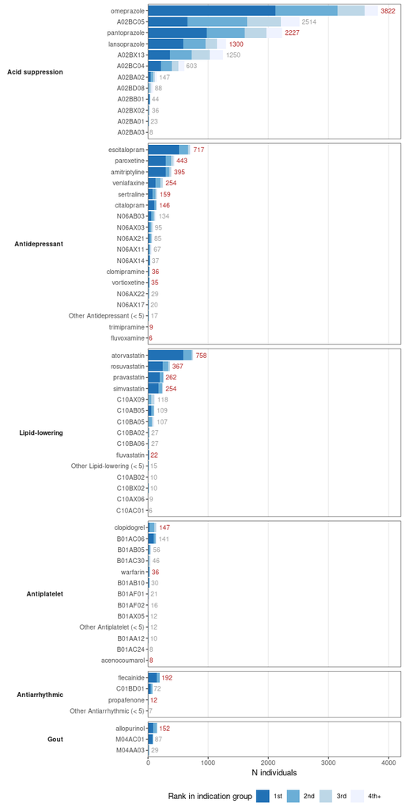

```r
dispensings_in_indication_groups <- dplyr::semi_join(
  dispensings, dplyr::distinct(drug_indication_map, atc3), by = "atc3"
)
pgx_drug_names <- unique(drug_indication_map[["drug_name"]])

drug_rank_in_group <- dplyr::inner_join(
  dplyr::distinct(cohort, individual_id, atc3),
  dispensings_in_indication_groups,
  by = c("individual_id", "atc3"),
  relationship = "one-to-many"
) |>
  dplyr::mutate(is_pgx_drug = .data[["drug_name"]] %in% pgx_drug_names) |>
  dplyr::left_join(
    dplyr::mutate(
      dplyr::distinct(cohort, individual_id, drug_name), in_cohort = TRUE
    ),
    by = c("individual_id", "drug_name")
  ) |>
  # Keep every non-PGx alternative, but drugs of individuals that are in the
  # cohort (because we only focus on incident users in group that had at least one PGx drug)
  dplyr::filter(!.data[["is_pgx_drug"]] | !is.na(.data[["in_cohort"]])) |>
  dplyr::group_by(individual_id, atc3) |>
  dplyr::arrange(date, .by_group = TRUE) |>
  dplyr::distinct(individual_id, atc3, drug_name, .keep_all = TRUE) |>
  dplyr::mutate(rank_in_class = dplyr::row_number()) |>
  dplyr::ungroup() |>
  dplyr::inner_join(
    dplyr::distinct(drug_indication_map, atc3, indication_group), by = "atc3"
  ) |>
  dplyr::mutate(
    label_type = dplyr::if_else(
      .data[["drug_name"]] %in% pgx_drug_names, "PGx drug", "ATC7 alternative"
    ),
    rank_label = factor(
      dplyr::case_when(
        .data[["rank_in_class"]] == 1L ~ "1st",
        .data[["rank_in_class"]] == 2L ~ "2nd",
        .data[["rank_in_class"]] == 3L ~ "3rd",
        .default = "4th+"
      ),
      levels = c("1st", "2nd", "3rd", "4th+")
    )
  ) |>
  dplyr::count(indication_group, drug_name, label_type, rank_label) |>
  dplyr::mutate(drug_n = sum(.data[["n"]]), .by = "drug_name") |>
  dplyr::mutate(
    drug_name = dplyr::if_else(
      .data[["drug_n"]] <= 5L,
      sprintf("Other %s (< 5)", .data[["indication_group"]]),
      .data[["drug_name"]]
    ),
    label_type = dplyr::if_else(
      .data[["drug_n"]] <= 5L, "ATC7 alternative", .data[["label_type"]]
    )
  ) |>
  dplyr::count(
    indication_group, drug_name, label_type, rank_label, wt = .data[["n"]]
  ) |>
  dplyr::mutate(class_n = sum(.data[["n"]]), .by = "indication_group") |>
  dplyr::mutate(drug_n = sum(.data[["n"]]), .by = "drug_name") |>
  dplyr::arrange(dplyr::desc(.data[["class_n"]]), dplyr::desc(.data[["drug_n"]])) |>
  dplyr::mutate(
    indication_group = forcats::fct_inorder(as.character(.data[["indication_group"]])),
    drug_name = forcats::fct_rev(forcats::fct_inorder(.data[["drug_name"]]))
  )

ggplot2::ggplot(
  drug_rank_in_group,
  ggplot2::aes(
    x = .data[["n"]], y = .data[["drug_name"]], fill = .data[["rank_label"]]
  )
) +
  ggplot2::geom_col(position = ggplot2::position_stack(reverse = TRUE)) +
  ggplot2::geom_text(
    data = \(d) {
      dplyr::summarise(
        d,
        total = sum(.data[["n"]]),
        .by = c("indication_group", "drug_name", "label_type")
      )
    },
    mapping = ggplot2::aes(
      x = .data[["total"]],
      y = .data[["drug_name"]],
      label = .data[["total"]],
      colour = .data[["label_type"]]
    ),
    hjust = -0.2,
    size = 2.8,
    inherit.aes = FALSE,
    show.legend = FALSE
  ) +
  ggplot2::facet_grid(
    indication_group ~ ., scales = "free_y", space = "free_y", switch = "y"
  ) +
  ggplot2::scale_fill_brewer(palette = "Blues", direction = -1) +
  ggplot2::scale_colour_manual(
    values = c("PGx drug" = "firebrick", "ATC7 alternative" = "grey60")
  ) +
  ggplot2::scale_x_continuous(expand = ggplot2::expansion(mult = c(0, 0.1))) +
  ggplot2::labs(
    x = "N individuals", y = NULL, fill = "Rank in indication group",
    title = NULL, subtitle = NULL
  ) +
  theme_pgx(base_size = 10)
```

## Outcome counts per drug

**Internal check**: the raw material of the models below. Worth reading before the forest plots: a drug with almost no switches cannot produce a usable switch estimate.

```r
short_term_counts_gt <- short_term_outcomes |>
  dplyr::group_by(indication_group, drug_name) |>
  dplyr::summarise(
    total = dplyr::n(),
    n_continued = sum(.data[["status"]] == "continued"),
    n_switched = sum(.data[["status"]] == "switched"),
    n_dropped = sum(.data[["status"]] == "dropped"),
    .groups = "drop"
  ) |>
  dplyr::arrange(.data[["indication_group"]]) |>
  gt::gt(groupname_col = "indication_group") |>
  gt::cols_label(
    drug_name = "Drug",
    total = "N",
    n_continued = "Continued",
    n_switched = "Switched",
    n_dropped = "Dropped",
  ) |>
  gt::tab_header(
    title = "Short-term outcomes per drug",
    subtitle = "Switch = another drug of the same indication group within the refill window"
  ) |>
  gt::tab_style(
    style = gt::cell_text(weight = "bold"),
    locations = gt::cells_row_groups()
  ) |>
  gt::tab_options(table.font.size = 10)

short_term_counts_gt
```

Short-term outcomes per drug

Switch = another drug of the same indication group within the refill window

| Drug | N | Continued | Switched | Dropped |
| --- | --- | --- | --- | --- |
| Lipid-lowering |  |  |  |  |
| atorvastatin | 727 | 522 | 65 | 140 |
| fluvastatin | 22 | 11 | 6 | 5 |
| pravastatin | 258 | 175 | 21 | 62 |
| rosuvastatin | 355 | 261 | 29 | 65 |
| simvastatin | 248 | 172 | 21 | 55 |
| Acid suppression |  |  |  |  |
| lansoprazole | 1275 | 204 | 244 | 827 |
| omeprazole | 3770 | 568 | 529 | 2673 |
| pantoprazole | 2180 | 398 | 354 | 1428 |
| Antidepressant |  |  |  |  |
| amitriptyline | 385 | 103 | 50 | 232 |
| citalopram | 146 | 75 | 16 | 55 |
| clomipramine | 35 | 16 | 6 | 13 |
| doxepin | 4 | 3 | 1 | 0 |
| escitalopram | 713 | 422 | 60 | 231 |
| fluvoxamine | 6 | 2 | 2 | 2 |
| imipramine | 1 | 1 | 0 | 0 |
| paroxetine | 441 | 237 | 44 | 160 |
| sertraline | 155 | 80 | 27 | 48 |
| trimipramine | 9 | 1 | 3 | 5 |
| venlafaxine | 254 | 138 | 39 | 77 |
| vortioxetine | 34 | 19 | 3 | 12 |
| Antiplatelet |  |  |  |  |
| acenocoumarol | 8 | 3 | 3 | 2 |
| clopidogrel | 145 | 41 | 87 | 17 |
| warfarin | 36 | 20 | 12 | 4 |
| Gout |  |  |  |  |
| allopurinol | 151 | 78 | 28 | 45 |
| Antiarrhythmic |  |  |  |  |
| flecainide | 191 | 151 | 7 | 33 |
| propafenone | 12 | 6 | 2 | 4 |

**LaTeX source**

````r
cat("```latex\n", gt::as_latex(short_term_counts_gt), "\n```\n", sep="")
````

```latex
\begin{table}
\caption*{
{\large Short-term outcomes per drug} \\
{\small Switch = another drug of the same indication group within the refill window}
}
\fontsize{7.5pt}{9.0pt}\selectfont
\begin{tabular*}{\linewidth}{@{\extracolsep{\fill}}lrrrr}
\toprule
Drug & N & Continued & Switched & Dropped \\
\midrule\addlinespace[2.5pt]
\multicolumn{5}{l}{{\bfseries Lipid-lowering}} \\[2.5pt]
\midrule\addlinespace[2.5pt]
atorvastatin & 727 & 522 & 65 & 140 \\
fluvastatin & 22 & 11 & 6 & 5 \\
pravastatin & 258 & 175 & 21 & 62 \\
rosuvastatin & 355 & 261 & 29 & 65 \\
simvastatin & 248 & 172 & 21 & 55 \\
\midrule\addlinespace[2.5pt]
\multicolumn{5}{l}{{\bfseries Acid suppression}} \\[2.5pt]
\midrule\addlinespace[2.5pt]
lansoprazole & 1275 & 204 & 244 & 827 \\
omeprazole & 3770 & 568 & 529 & 2673 \\
pantoprazole & 2180 & 398 & 354 & 1428 \\
\midrule\addlinespace[2.5pt]
\multicolumn{5}{l}{{\bfseries Antidepressant}} \\[2.5pt]
\midrule\addlinespace[2.5pt]
amitriptyline & 385 & 103 & 50 & 232 \\
citalopram & 146 & 75 & 16 & 55 \\
clomipramine & 35 & 16 & 6 & 13 \\
doxepin & 4 & 3 & 1 & 0 \\
escitalopram & 713 & 422 & 60 & 231 \\
fluvoxamine & 6 & 2 & 2 & 2 \\
imipramine & 1 & 1 & 0 & 0 \\
paroxetine & 441 & 237 & 44 & 160 \\
sertraline & 155 & 80 & 27 & 48 \\
trimipramine & 9 & 1 & 3 & 5 \\
venlafaxine & 254 & 138 & 39 & 77 \\
vortioxetine & 34 & 19 & 3 & 12 \\
\midrule\addlinespace[2.5pt]
\multicolumn{5}{l}{{\bfseries Antiplatelet}} \\[2.5pt]
\midrule\addlinespace[2.5pt]
acenocoumarol & 8 & 3 & 3 & 2 \\
clopidogrel & 145 & 41 & 87 & 17 \\
warfarin & 36 & 20 & 12 & 4 \\
\midrule\addlinespace[2.5pt]
\multicolumn{5}{l}{{\bfseries Gout}} \\[2.5pt]
\midrule\addlinespace[2.5pt]
allopurinol & 151 & 78 & 28 & 45 \\
\midrule\addlinespace[2.5pt]
\multicolumn{5}{l}{{\bfseries Antiarrhythmic}} \\[2.5pt]
\midrule\addlinespace[2.5pt]
flecainide & 191 & 151 & 7 & 33 \\
propafenone & 12 & 6 & 2 & 4 \\
\bottomrule
\end{tabular*}
\end{table}
```

**Internal check**: the same, for the episode-based (long-term) table.

```r
episode_counts_gt <- treatment_episodes |>
  dplyr::group_by(indication_group, drug_name) |>
  dplyr::summarise(
    n_episodes = dplyr::n(),
    n_continued = sum(.data[["event"]] == 0L),
    n_switched = sum(.data[["event"]] == 1L),
    n_dropped = sum(.data[["event"]] == 2L),
    median_fu_months = median(.data[["time"]]),
    .groups = "drop"
  ) |>
  dplyr::arrange(.data[["indication_group"]], dplyr::desc(.data[["n_episodes"]])) |>
  gt::gt(groupname_col = "indication_group") |>
  gt::cols_label(
    drug_name = "Drug",
    n_episodes = "N episodes",
    n_continued = "Continued",
    n_switched = "Switched",
    n_dropped = "Dropped",
    median_fu_months = "Median follow-up (months)"
  ) |>
  gt::tab_header(
    title = "Episode outcomes per drug",
    subtitle = "Switch = another drug of the same indication group within the refill window"
  ) |>
  gt::tab_style(
    style = gt::cell_text(weight = "bold"),
    locations = gt::cells_row_groups()
  ) |>
  gt::tab_options(table.font.size = 10)

episode_counts_gt
```

Episode outcomes per drug

Switch = another drug of the same indication group within the refill window

| Drug | N episodes | Continued | Switched | Dropped | Median follow-up (months) |
| --- | --- | --- | --- | --- | --- |
| Lipid-lowering |  |  |  |  |  |
| atorvastatin | 1426 | 378 | 193 | 855 | 5.0 |
| rosuvastatin | 803 | 146 | 93 | 564 | 6.0 |
| pravastatin | 767 | 79 | 74 | 614 | 4.0 |
| simvastatin | 494 | 98 | 56 | 340 | 5.0 |
| fluvastatin | 33 | 6 | 9 | 18 | 6.0 |
| Acid suppression |  |  |  |  |  |
| omeprazole | 8128 | 376 | 1107 | 6645 | 1.0 |
| pantoprazole | 3614 | 227 | 622 | 2765 | 1.0 |
| lansoprazole | 1963 | 103 | 378 | 1482 | 1.0 |
| Antidepressant |  |  |  |  |  |
| escitalopram | 1255 | 80 | 124 | 1051 | 3.0 |
| paroxetine | 716 | 65 | 86 | 565 | 3.0 |
| amitriptyline | 552 | 49 | 72 | 431 | 1.0 |
| venlafaxine | 401 | 38 | 58 | 305 | 4.0 |
| citalopram | 272 | 10 | 24 | 238 | 3.0 |
| sertraline | 240 | 25 | 36 | 179 | 3.0 |
| clomipramine | 53 | 6 | 6 | 41 | 3.0 |
| vortioxetine | 40 | 8 | 6 | 26 | 4.0 |
| trimipramine | 10 | 0 | 4 | 6 | 1.5 |
| doxepin | 8 | 1 | 1 | 6 | 4.5 |
| imipramine | 8 | 0 | 2 | 6 | 6.0 |
| fluvoxamine | 6 | 0 | 2 | 4 | 2.0 |
| Antiplatelet |  |  |  |  |  |
| clopidogrel | 206 | 34 | 115 | 57 | 7.0 |
| warfarin | 48 | 14 | 8 | 26 | 9.0 |
| acenocoumarol | 13 | 1 | 5 | 7 | 5.0 |
| Gout |  |  |  |  |  |
| allopurinol | 299 | 56 | 21 | 222 | 3.0 |
| Antiarrhythmic |  |  |  |  |  |
| flecainide | 295 | 85 | 27 | 183 | 10.0 |
| propafenone | 13 | 5 | 4 | 4 | 4.0 |

**LaTeX source**

````r
cat("```latex\n", gt::as_latex(episode_counts_gt), "\n```\n", sep="")
````

```latex
\begin{table}
\caption*{
{\large Episode outcomes per drug} \\
{\small Switch = another drug of the same indication group within the refill window}
}
\fontsize{7.5pt}{9.0pt}\selectfont
\begin{tabular*}{\linewidth}{@{\extracolsep{\fill}}lrrrrr}
\toprule
Drug & N episodes & Continued & Switched & Dropped & Median follow-up (months) \\
\midrule\addlinespace[2.5pt]
\multicolumn{6}{l}{{\bfseries Lipid-lowering}} \\[2.5pt]
\midrule\addlinespace[2.5pt]
atorvastatin & 1426 & 378 & 193 & 855 & 5.0 \\
rosuvastatin & 803 & 146 & 93 & 564 & 6.0 \\
pravastatin & 767 & 79 & 74 & 614 & 4.0 \\
simvastatin & 494 & 98 & 56 & 340 & 5.0 \\
fluvastatin & 33 & 6 & 9 & 18 & 6.0 \\
\midrule\addlinespace[2.5pt]
\multicolumn{6}{l}{{\bfseries Acid suppression}} \\[2.5pt]
\midrule\addlinespace[2.5pt]
omeprazole & 8128 & 376 & 1107 & 6645 & 1.0 \\
pantoprazole & 3614 & 227 & 622 & 2765 & 1.0 \\
lansoprazole & 1963 & 103 & 378 & 1482 & 1.0 \\
\midrule\addlinespace[2.5pt]
\multicolumn{6}{l}{{\bfseries Antidepressant}} \\[2.5pt]
\midrule\addlinespace[2.5pt]
escitalopram & 1255 & 80 & 124 & 1051 & 3.0 \\
paroxetine & 716 & 65 & 86 & 565 & 3.0 \\
amitriptyline & 552 & 49 & 72 & 431 & 1.0 \\
venlafaxine & 401 & 38 & 58 & 305 & 4.0 \\
citalopram & 272 & 10 & 24 & 238 & 3.0 \\
sertraline & 240 & 25 & 36 & 179 & 3.0 \\
clomipramine & 53 & 6 & 6 & 41 & 3.0 \\
vortioxetine & 40 & 8 & 6 & 26 & 4.0 \\
trimipramine & 10 & 0 & 4 & 6 & 1.5 \\
doxepin & 8 & 1 & 1 & 6 & 4.5 \\
imipramine & 8 & 0 & 2 & 6 & 6.0 \\
fluvoxamine & 6 & 0 & 2 & 4 & 2.0 \\
\midrule\addlinespace[2.5pt]
\multicolumn{6}{l}{{\bfseries Antiplatelet}} \\[2.5pt]
\midrule\addlinespace[2.5pt]
clopidogrel & 206 & 34 & 115 & 57 & 7.0 \\
warfarin & 48 & 14 & 8 & 26 & 9.0 \\
acenocoumarol & 13 & 1 & 5 & 7 & 5.0 \\
\midrule\addlinespace[2.5pt]
\multicolumn{6}{l}{{\bfseries Gout}} \\[2.5pt]
\midrule\addlinespace[2.5pt]
allopurinol & 299 & 56 & 21 & 222 & 3.0 \\
\midrule\addlinespace[2.5pt]
\multicolumn{6}{l}{{\bfseries Antiarrhythmic}} \\[2.5pt]
\midrule\addlinespace[2.5pt]
flecainide & 295 & 85 & 27 & 183 & 10.0 \\
propafenone & 13 & 5 & 4 & 4 & 4.0 \\
\bottomrule
\end{tabular*}
\end{table}
```

## PGx predisposition prevalence

Share of individuals carrying an actionable predisposition, per drug and per recommendation category. This is what determines how much power each model has: a category carried by 2 % of users of a drug cannot support an estimate however many individuals take it.

**Paper output**: Figure `\ref{fig:pgx-prevalence}` (`figures/pgx-prevalence.png`)

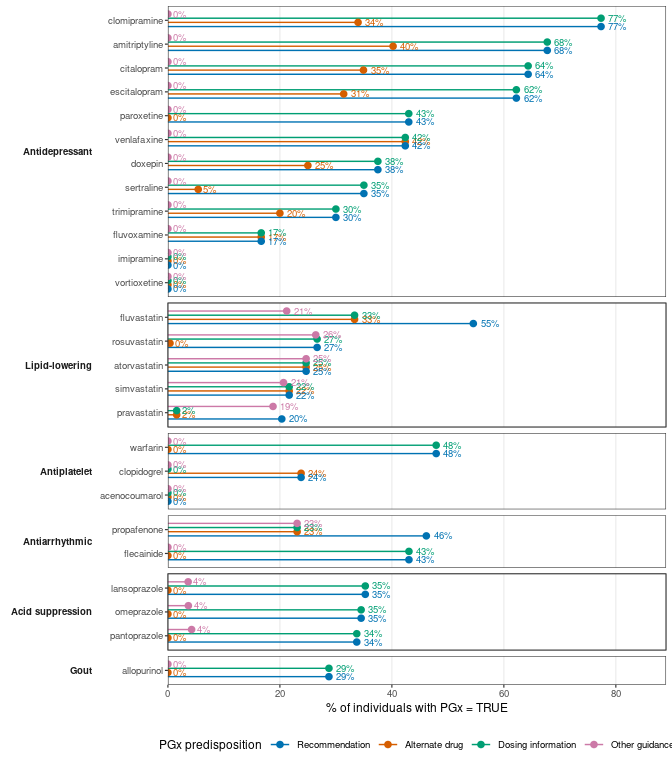

```r
pgx_prevalence <- treatment_episodes |>
  tidyr::pivot_longer(
    dplyr::all_of(pgx_variables), names_to = "pgx_var", values_to = "pgx_value"
  ) |>
  dplyr::filter(!is.na(.data[["pgx_value"]])) |>
  dplyr::group_by(indication_group, drug_name, pgx_var) |>
  dplyr::summarise(pct_true = 100 * mean(.data[["pgx_value"]]), .groups = "drop") |>
  dplyr::mutate(pgx_var = factor(.data[["pgx_var"]], levels = pgx_variables)) |>
  dplyr::mutate(drug_max = max(.data[["pct_true"]]), .by = "drug_name") |>
  dplyr::mutate(class_max = max(.data[["pct_true"]]), .by = "indication_group") |>
  dplyr::arrange(dplyr::desc(.data[["class_max"]]), dplyr::desc(.data[["drug_max"]])) |>
  dplyr::mutate(
    drug_name = forcats::fct_rev(forcats::fct_inorder(.data[["drug_name"]])),
    indication_group = forcats::fct_inorder(as.character(.data[["indication_group"]]))
  )

ggplot2::ggplot(
  pgx_prevalence,
  ggplot2::aes(
    x = .data[["pct_true"]], y = .data[["drug_name"]], colour = .data[["pgx_var"]]
  )
) +
  ggplot2::geom_linerange(
    ggplot2::aes(xmin = 0, xmax = .data[["pct_true"]]),
    position = ggplot2::position_dodge(width = 0.7),
    linewidth = 0.5
  ) +
  ggplot2::geom_point(position = ggplot2::position_dodge(width = 0.7), size = 2) +
  ggplot2::geom_text(
    ggplot2::aes(label = sprintf("%.0f%%", .data[["pct_true"]])),
    position = ggplot2::position_dodge(width = 0.7),
    hjust = -0.4,
    size = 2.5,
    show.legend = FALSE
  ) +
  ggplot2::facet_grid(
    indication_group ~ ., scales = "free_y", space = "free_y", switch = "y"
  ) +
  ggplot2::scale_x_continuous(
    expand = ggplot2::expansion(mult = c(0, 0.15)), limits = c(0, NA)
  ) +
  ggplot2::scale_colour_manual(values = pgx_var_colours, labels = pgx_labels) +
  ggplot2::labs(
    x = "% of individuals with PGx = TRUE", y = NULL, colour = "PGx predisposition"
  ) +
  theme_pgx(base_size = 9)
```

# Short-term outcomes: multinomial regression

One multinomial model per drug × PGx predisposition: `status ~ PGx + age_first + sex`, with **continued** as the reference outcome. The exponentiated coefficients are relative risk ratios (RRR): the risk of switching, or of dropping, relative to continuing, for carriers versus non-carriers.

A model is only fitted if it can support one: at least 5 individuals in every PGx × outcome cell, at least 15 individuals per outcome, and both PGx values present. Models that fail to converge, or that return an implausibly large standard error (> 10), are discarded rather than reported.

p-values are BH-adjusted **within indication group × PGx predisposition × outcome**, and only across the PGx coefficients: the age and sex coefficients are reported but do not enter the correction.

```r
# An empty or near-empty cell in the PGx x outcome table produces
# coefficients that are numerically huge and meaningless
passes_filter <- function(sub, pgx_var, outcome_col) {
  if (dplyr::n_distinct(stats::na.omit(sub[[pgx_var]])) < 2L) {
    return(FALSE)
  }
  tab <- table(sub[[pgx_var]], sub[[outcome_col]])
  if (any(tab < min_per_cell)) {
    return(FALSE)
  }
  if (any(rowSums(tab > 0) < ncol(tab))) {
    return(FALSE)
  }
  if (any(colSums(tab) < min_events)) {
    return(FALSE)
  }
  TRUE
}

fit_multinom_one <- function(df, drug_name, pgx_var) {
  sub <- dplyr::filter(
    df, drug_name == .env[["drug_name"]], !is.na(.data[[pgx_var]])
  )
  if (!passes_filter(sub, pgx_var, "status")) {
    return(NULL)
  }
  fit <- tryCatch(
    nnet::multinom(
      stats::reformulate(c(pgx_var, "age_first", "sex"), "status"),
      data = sub,
      trace = FALSE,
      maxit = 200L
    ),
    error = \(e) NULL,
    warning = \(w) NULL
  )
  if (is.null(fit) || fit[["convergence"]] != 0L) {
    return(NULL)
  }
  s <- summary(fit)
  b <- s[["coefficients"]]
  se <- s[["standard.errors"]]
  # A standard error above 10 on a log scale means the estimate is not identified
  if (any(se > 10, na.rm = TRUE)) {
    return(NULL)
  }
  p <- 2 * stats::pnorm(abs(b / se), lower.tail = FALSE)
  purrr::map(rownames(b), \(lvl) {
    tibble::tibble(
      drug_name = drug_name,
      pgx_var = pgx_var,
      outcome = lvl,
      predictor = colnames(b),
      estimate = exp(b)[lvl, ],
      lo = exp(b - 1.96 * se)[lvl, ],
      hi = exp(b + 1.96 * se)[lvl, ],
      p_value = if (colnames(b)[1] == "(Intercept)") {
        c(NA_real_, p[lvl, -1])
      } else {
        p[lvl, ]
      },
      n = nrow(sub)
    )
  }) |>
    purrr::list_rbind()
}

# Every drug x PGx predisposition combination is attempted; the test above decide
# which ones actually produce a model
model_grid <- tidyr::expand_grid(
  drug_name = unique(drug_indication_map[["drug_name"]]),
  pgx_var = pgx_variables
)

# Separates the coefficient of interest from the adjustment terms, so that BH is applied
# to the former only
classify_coef <- function(predictor) {
  dplyr::case_when(
    stringr::str_starts(predictor, paste(pgx_variables, collapse = "|")) ~ "PGx (interest)",
    stringr::str_starts(predictor, "age") ~ "Age",
    stringr::str_starts(predictor, "sex") ~ "Sex",
    .default = "Other"
  )
}
```

```r
multinom_res <- purrr::pmap(
  model_grid,
  \(drug_name, pgx_var) fit_multinom_one(short_term_outcomes, drug_name, pgx_var)
) |>
  purrr::list_rbind() |>
  dplyr::filter(.data[["predictor"]] != "(Intercept)") |>
  dplyr::inner_join(
    dplyr::distinct(drug_indication_map, drug_name, indication_group),
    by = "drug_name"
  ) |>
  dplyr::mutate(
    coef_type = classify_coef(.data[["predictor"]]),
    is_pgx = .data[["coef_type"]] == "PGx (interest)",
    pgx_var = factor(.data[["pgx_var"]], levels = pgx_variables),
    indication_group = factor(.data[["indication_group"]], levels = indication_levels)
  ) |>
  dplyr::group_by(
    .data[["indication_group"]], .data[["pgx_var"]], .data[["outcome"]]
  ) |>
  dplyr::mutate(p_adj = bh_within(.data[["p_value"]], .data[["is_pgx"]])) |>
  dplyr::ungroup()
```

**Paper output**: Figure `\ref{fig:multinom}` (`figures/fig-2.png`)

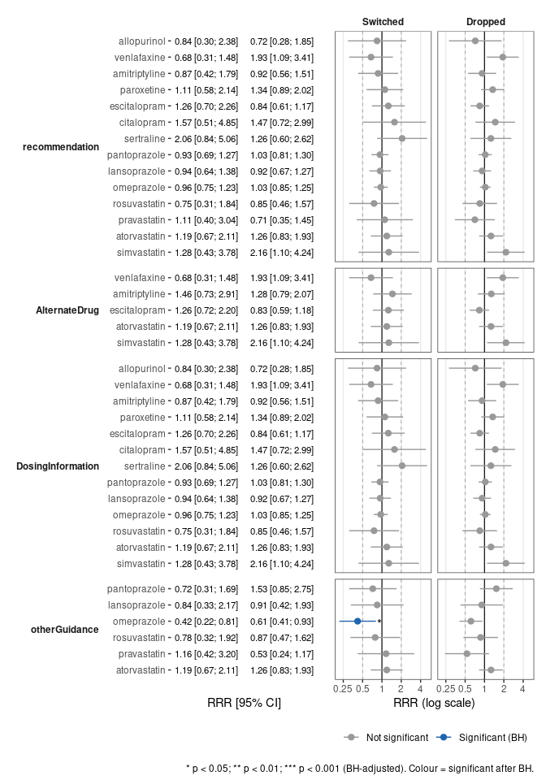

```r
multinom_res |>
  dplyr::filter(.data[["is_pgx"]]) |>
  dplyr::mutate(
    outcome = factor(
      .data[["outcome"]],
      levels = c("switched", "dropped"),
      labels = c("Switched", "Dropped")
    )
  ) |>
  make_forest(
    y_col = "drug_name",
    facet_row = "pgx_var",
    facet_col = "outcome",
    order_col = "indication_group",
    colour_col = "indication_group",
    x_label = "RRR (log scale)",
    ci_label = "RRR [95% CI]",
    title = NULL,
    subtitle = NULL
  )
```

**Paper output**: Table `\ref{tab:multinom-full-model}`. Restricted to models where at least one coefficient reaches p < 0.05, so the table reports the models worth reading rather than all of them.

```r
multinom_res_gt <- multinom_res |>
  dplyr::mutate(
    outcome = factor(
      .data[["outcome"]],
      levels = c("switched", "dropped"),
      labels = c("Switched", "Dropped")
    )
  ) |>
  dplyr::arrange(
    .data[["indication_group"]],
    .data[["drug_name"]],
    .data[["pgx_var"]],
    .data[["outcome"]]
  ) |>
  add_significance("p_adj") |>
  dplyr::group_by(drug_name, pgx_var, outcome) |>
  dplyr::filter(any(p_value <= 0.05)) |>
  make_result_gt(
    group_cols = c("indication_group", "drug_name"),
    extra_cols = c("pgx_var", "outcome", "predictor", "n"),
    estimate_label = "RRR [95% CI]",
    title = NULL,
    subtitle = NULL
  )

multinom_res_gt
```

| pgx_var | outcome | predictor | n | RRR [95% CI] | p | p (BH) |
| --- | --- | --- | --- | --- | --- | --- |
| Lipid-lowering - atorvastatin |  |  |  |  |  |  |
| recommendation | Dropped | recommendationTRUE | 727 | 1.26 [0.83; 1.93] | 0.282 | 0.461 |
| recommendation | Dropped | age_first | 727 | 0.95 [0.93; 0.97] | <0.001 | - |
| recommendation | Dropped | sexfemale | 727 | 2.20 [1.50; 3.23] | <0.001 | - |
| AlternateDrug | Dropped | AlternateDrugTRUE | 727 | 1.26 [0.83; 1.93] | 0.282 | 0.282 |
| AlternateDrug | Dropped | age_first | 727 | 0.95 [0.93; 0.97] | <0.001 | - |
| AlternateDrug | Dropped | sexfemale | 727 | 2.20 [1.50; 3.23] | <0.001 | - |
| DosingInformation | Dropped | DosingInformationTRUE | 727 | 1.26 [0.83; 1.93] | 0.282 | 0.422 |
| DosingInformation | Dropped | age_first | 727 | 0.95 [0.93; 0.97] | <0.001 | - |
| DosingInformation | Dropped | sexfemale | 727 | 2.20 [1.50; 3.23] | <0.001 | - |
| otherGuidance | Dropped | otherGuidanceTRUE | 727 | 1.26 [0.83; 1.93] | 0.282 | 0.422 |
| otherGuidance | Dropped | age_first | 727 | 0.95 [0.93; 0.97] | <0.001 | - |
| otherGuidance | Dropped | sexfemale | 727 | 2.20 [1.50; 3.23] | <0.001 | - |
| Lipid-lowering - rosuvastatin |  |  |  |  |  |  |
| recommendation | Dropped | recommendationTRUE | 355 | 0.85 [0.46; 1.57] | 0.594 | 0.594 |
| recommendation | Dropped | age_first | 355 | 0.96 [0.93; 1.00] | 0.030 | - |
| recommendation | Dropped | sexfemale | 355 | 1.16 [0.67; 2.02] | 0.587 | - |
| DosingInformation | Dropped | DosingInformationTRUE | 355 | 0.85 [0.46; 1.57] | 0.594 | 0.594 |
| DosingInformation | Dropped | age_first | 355 | 0.96 [0.93; 1.00] | 0.030 | - |
| DosingInformation | Dropped | sexfemale | 355 | 1.16 [0.67; 2.02] | 0.587 | - |
| otherGuidance | Dropped | otherGuidanceTRUE | 355 | 0.87 [0.47; 1.62] | 0.662 | 0.662 |
| otherGuidance | Dropped | age_first | 355 | 0.96 [0.93; 1.00] | 0.030 | - |
| otherGuidance | Dropped | sexfemale | 355 | 1.17 [0.67; 2.02] | 0.582 | - |
| Lipid-lowering - simvastatin |  |  |  |  |  |  |
| recommendation | Dropped | recommendationTRUE | 248 | 2.16 [1.10; 4.24] | 0.025 | 0.102 |
| recommendation | Dropped | age_first | 248 | 0.98 [0.94; 1.02] | 0.379 | - |
| recommendation | Dropped | sexfemale | 248 | 1.68 [0.90; 3.17] | 0.106 | - |
| AlternateDrug | Dropped | AlternateDrugTRUE | 248 | 2.16 [1.10; 4.24] | 0.025 | 0.051 |
| AlternateDrug | Dropped | age_first | 248 | 0.98 [0.94; 1.02] | 0.379 | - |
| AlternateDrug | Dropped | sexfemale | 248 | 1.68 [0.90; 3.17] | 0.106 | - |

[output cut: 69 more lines]

**LaTeX source for overleaf document**

````r
cat("```latex\n", gt::as_latex(multinom_res_gt), "\n```\n", sep="")
````

```latex
\begin{table}
\fontsize{7.5pt}{9.0pt}\selectfont
\begin{tabular*}{\linewidth}{@{\extracolsep{\fill}}cclrllr}
\toprule
pgx\_var & outcome & predictor & n & RRR [95\% CI] & p & p (BH) \\
\midrule\addlinespace[2.5pt]
\multicolumn{7}{l}{{\bfseries Lipid-lowering - atorvastatin}} \\[2.5pt]
\midrule\addlinespace[2.5pt]
recommendation & Dropped & recommendationTRUE & 727 & 1.26 [0.83; 1.93] & 0.282 & 0.461 \\
recommendation & Dropped & age\_first & 727 & 0.95 [0.93; 0.97] & <0.001 & - \\
recommendation & Dropped & sexfemale & 727 & 2.20 [1.50; 3.23] & <0.001 & - \\
AlternateDrug & Dropped & AlternateDrugTRUE & 727 & 1.26 [0.83; 1.93] & 0.282 & 0.282 \\
AlternateDrug & Dropped & age\_first & 727 & 0.95 [0.93; 0.97] & <0.001 & - \\
AlternateDrug & Dropped & sexfemale & 727 & 2.20 [1.50; 3.23] & <0.001 & - \\
DosingInformation & Dropped & DosingInformationTRUE & 727 & 1.26 [0.83; 1.93] & 0.282 & 0.422 \\
DosingInformation & Dropped & age\_first & 727 & 0.95 [0.93; 0.97] & <0.001 & - \\
DosingInformation & Dropped & sexfemale & 727 & 2.20 [1.50; 3.23] & <0.001 & - \\
otherGuidance & Dropped & otherGuidanceTRUE & 727 & 1.26 [0.83; 1.93] & 0.282 & 0.422 \\
otherGuidance & Dropped & age\_first & 727 & 0.95 [0.93; 0.97] & <0.001 & - \\
otherGuidance & Dropped & sexfemale & 727 & 2.20 [1.50; 3.23] & <0.001 & - \\
\midrule\addlinespace[2.5pt]
\multicolumn{7}{l}{{\bfseries Lipid-lowering - rosuvastatin}} \\[2.5pt]
\midrule\addlinespace[2.5pt]
recommendation & Dropped & recommendationTRUE & 355 & 0.85 [0.46; 1.57] & 0.594 & 0.594 \\
recommendation & Dropped & age\_first & 355 & 0.96 [0.93; 1.00] & 0.030 & - \\
recommendation & Dropped & sexfemale & 355 & 1.16 [0.67; 2.02] & 0.587 & - \\
DosingInformation & Dropped & DosingInformationTRUE & 355 & 0.85 [0.46; 1.57] & 0.594 & 0.594 \\
DosingInformation & Dropped & age\_first & 355 & 0.96 [0.93; 1.00] & 0.030 & - \\
DosingInformation & Dropped & sexfemale & 355 & 1.16 [0.67; 2.02] & 0.587 & - \\
otherGuidance & Dropped & otherGuidanceTRUE & 355 & 0.87 [0.47; 1.62] & 0.662 & 0.662 \\
otherGuidance & Dropped & age\_first & 355 & 0.96 [0.93; 1.00] & 0.030 & - \\
otherGuidance & Dropped & sexfemale & 355 & 1.17 [0.67; 2.02] & 0.582 & - \\
\midrule\addlinespace[2.5pt]
\multicolumn{7}{l}{{\bfseries Lipid-lowering - simvastatin}} \\[2.5pt]
\midrule\addlinespace[2.5pt]
recommendation & Dropped & recommendationTRUE & 248 & 2.16 [1.10; 4.24] & 0.025 & 0.102 \\
recommendation & Dropped & age\_first & 248 & 0.98 [0.94; 1.02] & 0.379 & - \\
recommendation & Dropped & sexfemale & 248 & 1.68 [0.90; 3.17] & 0.106 & - \\
AlternateDrug & Dropped & AlternateDrugTRUE & 248 & 2.16 [1.10; 4.24] & 0.025 & 0.051 \\
AlternateDrug & Dropped & age\_first & 248 & 0.98 [0.94; 1.02] & 0.379 & - \\
AlternateDrug & Dropped & sexfemale & 248 & 1.68 [0.90; 3.17] & 0.106 & - \\
DosingInformation & Dropped & DosingInformationTRUE & 248 & 2.16 [1.10; 4.24] & 0.025 & 0.076 \\
DosingInformation & Dropped & age\_first & 248 & 0.98 [0.94; 1.02] & 0.379 & - \\
DosingInformation & Dropped & sexfemale & 248 & 1.68 [0.90; 3.17] & 0.106 & - \\
\midrule\addlinespace[2.5pt]
\multicolumn{7}{l}{{\bfseries Acid suppression - lansoprazole}} \\[2.5pt]
\midrule\addlinespace[2.5pt]
recommendation & Dropped & recommendationTRUE & 1275 & 0.92 [0.67; 1.27] & 0.604 & 0.819 \\
recommendation & Dropped & age\_first & 1275 & 0.98 [0.97; 0.99] & 0.006 & - \\
recommendation & Dropped & sexfemale & 1275 & 1.24 [0.91; 1.68] & 0.177 & - \\
DosingInformation & Dropped & DosingInformationTRUE & 1275 & 0.92 [0.67; 1.27] & 0.604 & 0.819 \\
DosingInformation & Dropped & age\_first & 1275 & 0.98 [0.97; 0.99] & 0.006 & - \\
DosingInformation & Dropped & sexfemale & 1275 & 1.24 [0.91; 1.68] & 0.177 & - \\
otherGuidance & Dropped & otherGuidanceTRUE & 1275 & 0.91 [0.42; 1.93] & 0.799 & 0.799 \\
otherGuidance & Dropped & age\_first & 1275 & 0.98 [0.97; 0.99] & 0.006 & - \\
otherGuidance & Dropped & sexfemale & 1275 & 1.23 [0.91; 1.68] & 0.180 & - \\
\midrule\addlinespace[2.5pt]
\multicolumn{7}{l}{{\bfseries Acid suppression - omeprazole}} \\[2.5pt]
\midrule\addlinespace[2.5pt]
recommendation & Dropped & recommendationTRUE & 3770 & 1.03 [0.85; 1.25] & 0.777 & 0.819 \\
recommendation & Dropped & age\_first & 3770 & 0.99 [0.98; 1.00] & 0.002 & - \\
recommendation & Dropped & sexfemale & 3770 & 0.77 [0.64; 0.93] & 0.006 & - \\
DosingInformation & Dropped & DosingInformationTRUE & 3770 & 1.03 [0.85; 1.25] & 0.777 & 0.819 \\
DosingInformation & Dropped & age\_first & 3770 & 0.99 [0.98; 1.00] & 0.002 & - \\
DosingInformation & Dropped & sexfemale & 3770 & 0.77 [0.64; 0.93] & 0.006 & - \\
otherGuidance & Switched & otherGuidanceTRUE & 3770 & 0.42 [0.22; 0.81] & 0.009 & 0.028 \\
otherGuidance & Switched & age\_first & 3770 & 1.00 [0.99; 1.01] & 0.884 & - \\
otherGuidance & Switched & sexfemale & 3770 & 0.87 [0.69; 1.11] & 0.263 & - \\
otherGuidance & Dropped & otherGuidanceTRUE & 3770 & 0.61 [0.41; 0.93] & 0.021 & 0.062 \\
otherGuidance & Dropped & age\_first & 3770 & 0.99 [0.98; 1.00] & 0.003 & - \\
otherGuidance & Dropped & sexfemale & 3770 & 0.77 [0.64; 0.92] & 0.005 & - \\
\midrule\addlinespace[2.5pt]
\multicolumn{7}{l}{{\bfseries Acid suppression - pantoprazole}} \\[2.5pt]
\midrule\addlinespace[2.5pt]
recommendation & Switched & recommendationTRUE & 2180 & 0.93 [0.69; 1.27] & 0.655 & 0.750 \\
recommendation & Switched & age\_first & 2180 & 0.98 [0.97; 0.99] & 0.006 & - \\
recommendation & Switched & sexfemale & 2180 & 0.92 [0.69; 1.22] & 0.558 & - \\
recommendation & Dropped & recommendationTRUE & 2180 & 1.03 [0.81; 1.30] & 0.819 & 0.819 \\
recommendation & Dropped & age\_first & 2180 & 0.97 [0.96; 0.98] & <0.001 & - \\
recommendation & Dropped & sexfemale & 2180 & 1.00 [0.80; 1.25] & 0.998 & - \\
DosingInformation & Switched & DosingInformationTRUE & 2180 & 0.93 [0.69; 1.27] & 0.655 & 0.750 \\
DosingInformation & Switched & age\_first & 2180 & 0.98 [0.97; 0.99] & 0.006 & - \\
DosingInformation & Switched & sexfemale & 2180 & 0.92 [0.69; 1.22] & 0.558 & - \\
DosingInformation & Dropped & DosingInformationTRUE & 2180 & 1.03 [0.81; 1.30] & 0.819 & 0.819 \\
DosingInformation & Dropped & age\_first & 2180 & 0.97 [0.96; 0.98] & <0.001 & - \\
DosingInformation & Dropped & sexfemale & 2180 & 1.00 [0.80; 1.25] & 0.998 & - \\
otherGuidance & Switched & otherGuidanceTRUE & 2180 & 0.72 [0.31; 1.69] & 0.451 & 0.677 \\
otherGuidance & Switched & age\_first & 2180 & 0.98 [0.97; 0.99] & 0.006 & - \\
otherGuidance & Switched & sexfemale & 2180 & 0.91 [0.69; 1.22] & 0.545 & - \\
otherGuidance & Dropped & otherGuidanceTRUE & 2180 & 1.53 [0.85; 2.75] & 0.157 & 0.235 \\
otherGuidance & Dropped & age\_first & 2180 & 0.97 [0.96; 0.98] & <0.001 & - \\
otherGuidance & Dropped & sexfemale & 2180 & 1.01 [0.80; 1.26] & 0.949 & - \\
\midrule\addlinespace[2.5pt]
\multicolumn{7}{l}{{\bfseries Antidepressant - citalopram}} \\[2.5pt]
\midrule\addlinespace[2.5pt]
recommendation & Switched & recommendationTRUE & 146 & 1.57 [0.51; 4.85] & 0.436 & 0.670 \\
recommendation & Switched & age\_first & 146 & 1.00 [0.94; 1.05] & 0.861 & - \\
recommendation & Switched & sexfemale & 146 & 0.30 [0.10; 0.91] & 0.034 & - \\
DosingInformation & Switched & DosingInformationTRUE & 146 & 1.57 [0.51; 4.85] & 0.436 & 0.670 \\
DosingInformation & Switched & age\_first & 146 & 1.00 [0.94; 1.05] & 0.861 & - \\
DosingInformation & Switched & sexfemale & 146 & 0.30 [0.10; 0.91] & 0.034 & - \\
\midrule\addlinespace[2.5pt]
\multicolumn{7}{l}{{\bfseries Antidepressant - venlafaxine}} \\[2.5pt]
\midrule\addlinespace[2.5pt]
recommendation & Dropped & recommendationTRUE & 254 & 1.93 [1.09; 3.41] & 0.024 & 0.143 \\
recommendation & Dropped & age\_first & 254 & 1.02 [0.99; 1.05] & 0.193 & - \\
recommendation & Dropped & sexfemale & 254 & 0.94 [0.51; 1.75] & 0.846 & - \\
AlternateDrug & Dropped & AlternateDrugTRUE & 254 & 1.93 [1.09; 3.41] & 0.024 & 0.072 \\
AlternateDrug & Dropped & age\_first & 254 & 1.02 [0.99; 1.05] & 0.193 & - \\
AlternateDrug & Dropped & sexfemale & 254 & 0.94 [0.51; 1.75] & 0.846 & - \\
DosingInformation & Dropped & DosingInformationTRUE & 254 & 1.93 [1.09; 3.41] & 0.024 & 0.143 \\
DosingInformation & Dropped & age\_first & 254 & 1.02 [0.99; 1.05] & 0.193 & - \\
DosingInformation & Dropped & sexfemale & 254 & 0.94 [0.51; 1.75] & 0.846 & - \\
\midrule\addlinespace[2.5pt]
\multicolumn{7}{l}{{\bfseries Gout - allopurinol}} \\[2.5pt]
\midrule\addlinespace[2.5pt]
recommendation & Dropped & recommendationTRUE & 151 & 0.72 [0.28; 1.85] & 0.493 & 0.493 \\
recommendation & Dropped & age\_first & 151 & 1.01 [0.97; 1.06] & 0.552 & - \\
recommendation & Dropped & sexfemale & 151 & 2.73 [1.16; 6.45] & 0.022 & - \\
DosingInformation & Dropped & DosingInformationTRUE & 151 & 0.72 [0.28; 1.85] & 0.493 & 0.493 \\
DosingInformation & Dropped & age\_first & 151 & 1.01 [0.97; 1.06] & 0.552 & - \\
DosingInformation & Dropped & sexfemale & 151 & 2.73 [1.16; 6.45] & 0.022 & - \\
\bottomrule
\end{tabular*}
\end{table}
```

# Long-term outcomes: Cox models pooled per indication group

Episodes of every drug in an indication group are pooled into one Cox proportional-hazards model, with time measured in months since the episode’s first dispensing. Pooling buys power, and stratifying by drug gives each drug x rank combination its own baseline hazard instead of assuming they share one.

Three specifications are reported:

| Specification | Event | Purpose |
| --- | --- | --- |
| Any discontinuation | switch or drop | the headline result |
| Drop only | drop; switchers censored | separates stopping from changing |
| First episode only | switch or drop, first episode | removes the within-individual repetition |

Covariates are checked against the proportional-hazards assumption with `cox.zph` and, if they violate it (p < 0.05), moved into the strata one at a time, worst first, until none remain. Age enters the strata discretised into five bins (< 40, 40-49, 50-59, 60-69, >= 70). The PGx variable and sex are never stratified.

Age here is `age_at_episode_start`, not the cohort’s `age_first`. The two differ for every episode after an individual’s first: `age_first` would be carried unchanged across episodes separated by years, whereas this model’s clock starts at each episode.

`cluster(individual_id)` gives robust standard errors, because one individual can contribute several episodes.

```r
candidate_covariates <- c("sex", "age_at_episode_start")
strata_covariates_pooled <- c("drug_name", "episode_rank")

fit_cox_iterative <- function(df, event_col, pgx_var, candidates, in_strata) {
  df_use <- dplyr::filter(df, !is.na(.data[[pgx_var]]))
  # Too few events, or no contrast in the exposure: not estimable
  if (sum(df_use[[event_col]]) < 10L) {
    return(NULL)
  }
  if (dplyr::n_distinct(stats::na.omit(df_use[[pgx_var]])) < 2L) {
    return(NULL)
  }
  in_model <- candidates
  in_strata <- in_strata
  fit <- NULL
  zph_tbl <- NULL
  # At most one pass per candidate covariate, plus a final pass once none is left
  for (i in seq_len(length(candidates) + 1L)) {
    terms <- c(pgx_var, in_model)
    if (length(in_strata) > 0L) {
      terms <- c(terms, sprintf("strata(%s)", paste(in_strata, collapse = ", ")))
    }
    form <- stats::as.formula(sprintf(
      "Surv(time, %s) ~ %s + cluster(individual_id)",
      event_col,
      paste(terms, collapse = " + ")
    ))
    # Age is continuous as a covariate but must be binned to be used as a stratum
    if ("age_at_episode_start" %in% in_strata) {
      df_final <- dplyr::mutate(
        df_use,
        age_at_episode_start = as.character(
          cut(age_at_episode_start, breaks = c(-Inf, 40, 50, 60, 70, Inf))
        )
      )
    } else {
      df_final <- df_use
    }
    fit <- tryCatch(survival::coxph(form, data = df_final), error = \(e) list(e = e))
    if (!is.null(fit[["e"]])) {
      return(NULL)
    }
    zph_tbl <- tryCatch(
      tibble::as_tibble(survival::cox.zph(fit)[["table"]], rownames = "term"),
      error = \(e) NULL
    )
    if (is.null(zph_tbl)) {
      break
    }
    violators <- zph_tbl |>
      dplyr::filter(
        !.data[["term"]] %in% c("GLOBAL", pgx_var, "sex"),
        .data[["p"]] < 0.05
      ) |>
      dplyr::pull("term") |>
      intersect(in_model)
    if (length(violators) == 0L) {
      break
    }
    worst <- zph_tbl |>
      dplyr::filter(.data[["term"]] %in% violators) |>
      dplyr::slice_min(.data[["p"]], n = 1L) |>
      dplyr::pull("term")
    in_model <- setdiff(in_model, worst)
    in_strata <- c(in_strata, worst)
  }
  # coxph drops rows with a missing covariate, so the individual count has to be taken
  # over the rows the model actually used, not over everything handed to it
  used <- df_final
  if (!is.null(fit[["na.action"]])) {
    used <- used[-as.integer(fit[["na.action"]]), ]
  }
  list(
    fit = fit,
    pgx_var = pgx_var,
    event_col = event_col,
    in_strata = in_strata,
    n_individuals = dplyr::n_distinct(used[["individual_id"]])
  )
}

tidy_cox <- function(fit_obj) {
  if (is.null(fit_obj)) {
    return(NULL)
  }
  s <- summary(fit_obj[["fit"]])
  coefs <- s[["coefficients"]]
  conf <- s[["conf.int"]]
  tibble::tibble(
    pgx_var = fit_obj[["pgx_var"]],
    event_col = fit_obj[["event_col"]],
    term = rownames(coefs),
    estimate = conf[, "exp(coef)"],
    lo = conf[, "lower .95"],
    hi = conf[, "upper .95"],
    p_value = coefs[, ncol(coefs)],
    n_individuals = fit_obj[["n_individuals"]],
    n_episodes = s[["n"]],
    n_event = s[["nevent"]],
    in_strata = paste(fit_obj[["in_strata"]], collapse = ", ")
  )
}

# The three specifications, fitted for each PGx predisposition
run_class_specs <- function(df_class, candidates, in_strata) {
  specs <- list(
    any_discontinuation = list(
      df = df_class, event_col = "event_any", label = "Any discontinuation"
    ),
    drop_only = list(
      df = df_class, event_col = "event_drop", label = "Drop only"
    ),
    first_only = list(
      df = df_class |>
        dplyr::group_by(individual_id) |>
        dplyr::arrange(.data[["episode_start"]], .by_group = TRUE) |>
        dplyr::slice(1L) |>
        dplyr::ungroup(),
      event_col = "event_any",
      label = "First episode only"
    )
  )
  purrr::imap(specs, \(sp, sp_name) {
    purrr::map(pgx_variables, \(pv) {
      fit_obj <- fit_cox_iterative(
        sp[["df"]], sp[["event_col"]], pv, candidates, in_strata
      )
      if (!is.null(fit_obj)) {
        dplyr::mutate(tidy_cox(fit_obj), spec = sp_name, spec_label = sp[["label"]])
      }
    }) |>
      purrr::list_rbind()
  }) |>
    purrr::list_rbind()
}
```

```r
cox_pooled_res <- treatment_episodes |>
  dplyr::group_by(indication_group) |>
  dplyr::group_split() |>
  purrr::map(\(df_class) {
    res <- run_class_specs(df_class, candidate_covariates, strata_covariates_pooled)
    if (nrow(res) == 0L) {
      return(NULL)
    }
    dplyr::mutate(res, indication_group = dplyr::first(df_class[["indication_group"]]))
  }) |>
  purrr::list_rbind() |>
  # Non-finite estimates come from models that technically converged but are still misspecified
  dplyr::filter(
    is.finite(.data[["estimate"]]),
    is.finite(.data[["lo"]]),
    is.finite(.data[["hi"]])
  ) |>
  dplyr::mutate(
    is_pgx = stringr::str_starts(
      .data[["term"]], paste(pgx_variables, collapse = "|")
    )
  ) |>
  dplyr::mutate(
    pgx_var = factor(.data[["pgx_var"]], levels = pgx_variables),
    indication_group = factor(.data[["indication_group"]], levels = indication_levels),
    spec_label = factor(
      .data[["spec_label"]],
      levels = c("Any discontinuation", "Drop only", "First episode only")
    )
  ) |>
  # BH across indication groups, within PGx predisposition x specification
  dplyr::group_by(.data[["pgx_var"]], .data[["spec"]]) |>
  dplyr::mutate(p_adj = bh_within(.data[["p_value"]], .data[["is_pgx"]])) |>
  dplyr::ungroup()
```

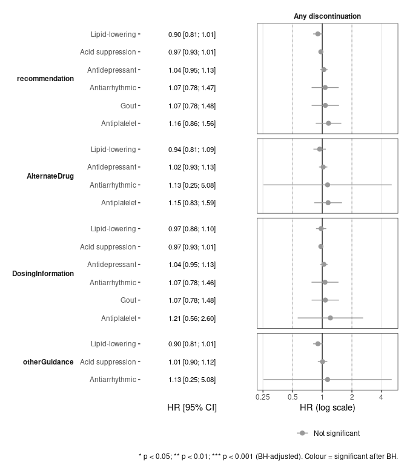

```r
cox_pooled_res |>
  dplyr::filter(.data[["is_pgx"]]) |>
  dplyr::filter(.data[["spec"]] == "any_discontinuation") |>
  make_forest(
    y_col = "indication_group",
    facet_row = "pgx_var",
    facet_col = "spec_label",
    x_label = "HR (log scale)",
    ci_label = "HR [95% CI]",
    title = NULL,
    subtitle = NULL
  )
```

**Paper output**: Table `\ref{tab:cox-full-model}`

```r
cox_pooled_res_gt <- cox_pooled_res |>
  dplyr::mutate(
    strata_fmt = dplyr::if_else(
      .data[["in_strata"]] == "", "-", .data[["in_strata"]]
    )
  ) |>
  dplyr::arrange(
    .data[["indication_group"]], .data[["spec_label"]], .data[["pgx_var"]]
  ) |>
  add_significance("p_adj") |>
  dplyr::filter(spec_label == "Any discontinuation") |>
  dplyr::group_by(indication_group, pgx_var) |>
  dplyr::filter(any(p_value <= 0.05)) |>
  make_result_gt(
    group_cols = c("indication_group"),
    extra_cols = c(
      "pgx_var", "term", "n_individuals", "n_episodes", "n_event", "strata_fmt"
    ),
    estimate_label = "HR [95% CI]",
    title = NULL,
    subtitle = NULL
  )

cox_pooled_res_gt
```

| pgx_var | term | n_individuals | n_episodes | n_event | strata_fmt | HR [95% CI] | p | p (BH) |
| --- | --- | --- | --- | --- | --- | --- | --- | --- |
| Lipid-lowering |  |  |  |  |  |  |  |  |
| recommendation | recommendationTRUE | 1310 | 3523 | 2816 | drug_name, episode_rank | 0.90 [0.81; 1.01] | 0.063 | 0.378 |
| recommendation | sexfemale | 1310 | 3523 | 2816 | drug_name, episode_rank | 1.17 [1.06; 1.29] | 0.002 | - |
| recommendation | age_at_episode_start | 1310 | 3523 | 2816 | drug_name, episode_rank | 0.99 [0.98; 0.99] | <0.001 | - |
| AlternateDrug | AlternateDrugTRUE | 1310 | 3523 | 2816 | drug_name, episode_rank | 0.94 [0.81; 1.09] | 0.414 | 0.827 |
| AlternateDrug | sexfemale | 1310 | 3523 | 2816 | drug_name, episode_rank | 1.17 [1.06; 1.30] | 0.002 | - |
| AlternateDrug | age_at_episode_start | 1310 | 3523 | 2816 | drug_name, episode_rank | 0.99 [0.98; 0.99] | <0.001 | - |
| DosingInformation | DosingInformationTRUE | 1310 | 3523 | 2816 | drug_name, episode_rank | 0.97 [0.86; 1.10] | 0.670 | 0.689 |
| DosingInformation | sexfemale | 1310 | 3523 | 2816 | drug_name, episode_rank | 1.18 [1.06; 1.30] | 0.002 | - |
| DosingInformation | age_at_episode_start | 1310 | 3523 | 2816 | drug_name, episode_rank | 0.99 [0.98; 0.99] | <0.001 | - |
| otherGuidance | otherGuidanceTRUE | 1310 | 3523 | 2816 | drug_name, episode_rank | 0.90 [0.81; 1.01] | 0.071 | 0.213 |
| otherGuidance | sexfemale | 1310 | 3523 | 2816 | drug_name, episode_rank | 1.17 [1.06; 1.29] | 0.002 | - |
| otherGuidance | age_at_episode_start | 1310 | 3523 | 2816 | drug_name, episode_rank | 0.99 [0.98; 0.99] | <0.001 | - |
| Acid suppression |  |  |  |  |  |  |  |  |
| recommendation | recommendationTRUE | 4990 | 13705 | 12999 | drug_name, episode_rank | 0.97 [0.93; 1.01] | 0.140 | 0.421 |
| recommendation | sexfemale | 4990 | 13705 | 12999 | drug_name, episode_rank | 0.98 [0.94; 1.02] | 0.411 | - |
| recommendation | age_at_episode_start | 4990 | 13705 | 12999 | drug_name, episode_rank | 0.99 [0.99; 0.99] | <0.001 | - |
| DosingInformation | DosingInformationTRUE | 4990 | 13705 | 12999 | drug_name, episode_rank | 0.97 [0.93; 1.01] | 0.140 | 0.689 |
| DosingInformation | sexfemale | 4990 | 13705 | 12999 | drug_name, episode_rank | 0.98 [0.94; 1.02] | 0.411 | - |
| DosingInformation | age_at_episode_start | 4990 | 13705 | 12999 | drug_name, episode_rank | 0.99 [0.99; 0.99] | <0.001 | - |
| otherGuidance | otherGuidanceTRUE | 4990 | 13705 | 12999 | drug_name, episode_rank | 1.01 [0.90; 1.12] | 0.900 | 0.900 |
| otherGuidance | sexfemale | 4990 | 13705 | 12999 | drug_name, episode_rank | 0.98 [0.94; 1.02] | 0.407 | - |
| otherGuidance | age_at_episode_start | 4990 | 13705 | 12999 | drug_name, episode_rank | 0.99 [0.99; 0.99] | <0.001 | - |
| Antidepressant |  |  |  |  |  |  |  |  |
| recommendation | recommendationTRUE | 1602 | 3561 | 3279 | drug_name, episode_rank, age_at_episode_start | 1.04 [0.95; 1.13] | 0.401 | 0.602 |
| recommendation | sexfemale | 1602 | 3561 | 3279 | drug_name, episode_rank, age_at_episode_start | 0.88 [0.80; 0.96] | 0.006 | - |
| AlternateDrug | AlternateDrugTRUE | 1602 | 3561 | 3279 | drug_name, episode_rank, age_at_episode_start | 1.02 [0.93; 1.13] | 0.671 | 0.871 |
| AlternateDrug | sexfemale | 1602 | 3561 | 3279 | drug_name, episode_rank, age_at_episode_start | 0.88 [0.80; 0.96] | 0.006 | - |
| DosingInformation | DosingInformationTRUE | 1602 | 3561 | 3279 | drug_name, episode_rank, age_at_episode_start | 1.04 [0.95; 1.13] | 0.401 | 0.689 |
| DosingInformation | sexfemale | 1602 | 3561 | 3279 | drug_name, episode_rank, age_at_episode_start | 0.88 [0.80; 0.96] | 0.006 | - |

**LaTeX source for overleaf document**

````r
cat("```latex\n", gt::as_latex(cox_pooled_res_gt), "\n```\n", sep="")
````

```latex
\begin{table}
\fontsize{7.5pt}{9.0pt}\selectfont
\begin{tabular*}{\linewidth}{@{\extracolsep{\fill}}clrrrlllr}
\toprule
pgx\_var & term & n\_individuals & n\_episodes & n\_event & strata\_fmt & HR [95\% CI] & p & p (BH) \\
\midrule\addlinespace[2.5pt]
\multicolumn{9}{l}{{\bfseries Lipid-lowering}} \\[2.5pt]
\midrule\addlinespace[2.5pt]
recommendation & recommendationTRUE & 1310 & 3523 & 2816 & drug\_name, episode\_rank & 0.90 [0.81; 1.01] & 0.063 & 0.378 \\
recommendation & sexfemale & 1310 & 3523 & 2816 & drug\_name, episode\_rank & 1.17 [1.06; 1.29] & 0.002 & - \\
recommendation & age\_at\_episode\_start & 1310 & 3523 & 2816 & drug\_name, episode\_rank & 0.99 [0.98; 0.99] & <0.001 & - \\
AlternateDrug & AlternateDrugTRUE & 1310 & 3523 & 2816 & drug\_name, episode\_rank & 0.94 [0.81; 1.09] & 0.414 & 0.827 \\
AlternateDrug & sexfemale & 1310 & 3523 & 2816 & drug\_name, episode\_rank & 1.17 [1.06; 1.30] & 0.002 & - \\
AlternateDrug & age\_at\_episode\_start & 1310 & 3523 & 2816 & drug\_name, episode\_rank & 0.99 [0.98; 0.99] & <0.001 & - \\
DosingInformation & DosingInformationTRUE & 1310 & 3523 & 2816 & drug\_name, episode\_rank & 0.97 [0.86; 1.10] & 0.670 & 0.689 \\
DosingInformation & sexfemale & 1310 & 3523 & 2816 & drug\_name, episode\_rank & 1.18 [1.06; 1.30] & 0.002 & - \\
DosingInformation & age\_at\_episode\_start & 1310 & 3523 & 2816 & drug\_name, episode\_rank & 0.99 [0.98; 0.99] & <0.001 & - \\
otherGuidance & otherGuidanceTRUE & 1310 & 3523 & 2816 & drug\_name, episode\_rank & 0.90 [0.81; 1.01] & 0.071 & 0.213 \\
otherGuidance & sexfemale & 1310 & 3523 & 2816 & drug\_name, episode\_rank & 1.17 [1.06; 1.29] & 0.002 & - \\
otherGuidance & age\_at\_episode\_start & 1310 & 3523 & 2816 & drug\_name, episode\_rank & 0.99 [0.98; 0.99] & <0.001 & - \\
\midrule\addlinespace[2.5pt]
\multicolumn{9}{l}{{\bfseries Acid suppression}} \\[2.5pt]
\midrule\addlinespace[2.5pt]
recommendation & recommendationTRUE & 4990 & 13705 & 12999 & drug\_name, episode\_rank & 0.97 [0.93; 1.01] & 0.140 & 0.421 \\
recommendation & sexfemale & 4990 & 13705 & 12999 & drug\_name, episode\_rank & 0.98 [0.94; 1.02] & 0.411 & - \\
recommendation & age\_at\_episode\_start & 4990 & 13705 & 12999 & drug\_name, episode\_rank & 0.99 [0.99; 0.99] & <0.001 & - \\
DosingInformation & DosingInformationTRUE & 4990 & 13705 & 12999 & drug\_name, episode\_rank & 0.97 [0.93; 1.01] & 0.140 & 0.689 \\
DosingInformation & sexfemale & 4990 & 13705 & 12999 & drug\_name, episode\_rank & 0.98 [0.94; 1.02] & 0.411 & - \\
DosingInformation & age\_at\_episode\_start & 4990 & 13705 & 12999 & drug\_name, episode\_rank & 0.99 [0.99; 0.99] & <0.001 & - \\
otherGuidance & otherGuidanceTRUE & 4990 & 13705 & 12999 & drug\_name, episode\_rank & 1.01 [0.90; 1.12] & 0.900 & 0.900 \\
otherGuidance & sexfemale & 4990 & 13705 & 12999 & drug\_name, episode\_rank & 0.98 [0.94; 1.02] & 0.407 & - \\
otherGuidance & age\_at\_episode\_start & 4990 & 13705 & 12999 & drug\_name, episode\_rank & 0.99 [0.99; 0.99] & <0.001 & - \\
\midrule\addlinespace[2.5pt]
\multicolumn{9}{l}{{\bfseries Antidepressant}} \\[2.5pt]
\midrule\addlinespace[2.5pt]
recommendation & recommendationTRUE & 1602 & 3561 & 3279 & drug\_name, episode\_rank, age\_at\_episode\_start & 1.04 [0.95; 1.13] & 0.401 & 0.602 \\
recommendation & sexfemale & 1602 & 3561 & 3279 & drug\_name, episode\_rank, age\_at\_episode\_start & 0.88 [0.80; 0.96] & 0.006 & - \\
AlternateDrug & AlternateDrugTRUE & 1602 & 3561 & 3279 & drug\_name, episode\_rank, age\_at\_episode\_start & 1.02 [0.93; 1.13] & 0.671 & 0.871 \\
AlternateDrug & sexfemale & 1602 & 3561 & 3279 & drug\_name, episode\_rank, age\_at\_episode\_start & 0.88 [0.80; 0.96] & 0.006 & - \\
DosingInformation & DosingInformationTRUE & 1602 & 3561 & 3279 & drug\_name, episode\_rank, age\_at\_episode\_start & 1.04 [0.95; 1.13] & 0.401 & 0.689 \\
DosingInformation & sexfemale & 1602 & 3561 & 3279 & drug\_name, episode\_rank, age\_at\_episode\_start & 0.88 [0.80; 0.96] & 0.006 & - \\
\bottomrule
\end{tabular*}
\end{table}
```

**Paper output**: Figure `\ref{fig:km}` (`figures/km-1.png` … `-6.png`, one per indication group).

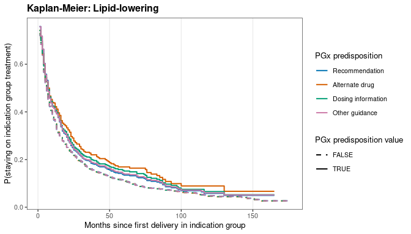

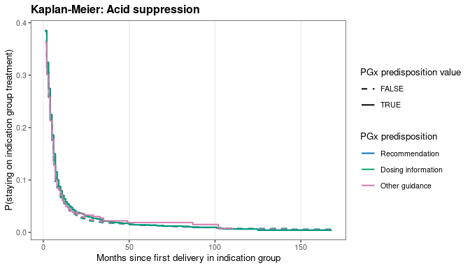

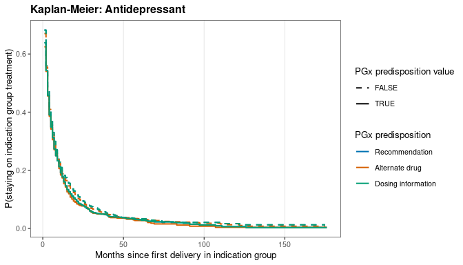

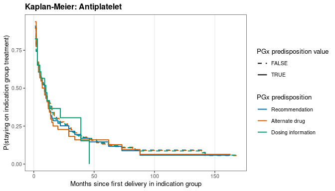

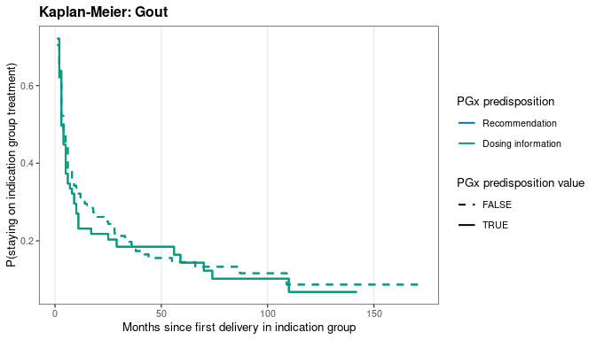

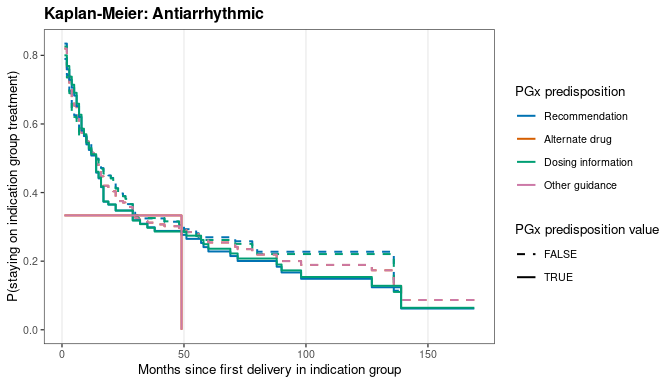

```r
km_build <- function(df_class, event_col = "event_any") {
  purrr::map(pgx_variables, \(pv) {
    sub <- dplyr::filter(df_class, !is.na(.data[[pv]]))
    if (dplyr::n_distinct(sub[[pv]]) < 2L || sum(sub[[event_col]]) < 5L) {
      return(NULL)
    }
    fit <- survival::survfit(
      stats::reformulate(pv, sprintf("Surv(time, %s)", event_col)), data = sub
    )
    tibble::tibble(
      time = fit[["time"]],
      surv = fit[["surv"]],
      pgx_value = stringr::str_remove(
        rep(names(fit[["strata"]]), fit[["strata"]]), sprintf("^%s=", pv)
      ),
      pgx_var = pv
    )
  }) |>
    purrr::list_rbind()
}

km_pooled <- treatment_episodes |>
  dplyr::group_by(indication_group) |>
  dplyr::group_split() |>
  purrr::map(\(df_class) {
    res <- km_build(df_class)
    if (nrow(res) == 0L) {
      return(NULL)
    }
    dplyr::mutate(res, indication_group = dplyr::first(df_class[["indication_group"]]))
  }) |>
  purrr::list_rbind()

purrr::walk(indication_levels, \(group) {
  sub <- dplyr::filter(km_pooled, indication_group == group)
  if (nrow(sub) == 0L) {
    return(invisible(NULL))
  }
  p <- sub |>
    dplyr::mutate(pgx_var = factor(.data[["pgx_var"]], levels = pgx_variables)) |>
    ggplot2::ggplot(ggplot2::aes(
      x = .data[["time"]],
      y = .data[["surv"]],
      colour = .data[["pgx_var"]],
      linetype = .data[["pgx_value"]],
      group = interaction(.data[["pgx_var"]], .data[["pgx_value"]])
    )) +
    ggplot2::geom_step(linewidth = 0.7) +
    ggplot2::scale_linetype_manual(values = c(`TRUE` = "solid", `FALSE` = "dashed")) +
    ggplot2::scale_colour_manual(values = pgx_var_colours, labels = pgx_labels) +
    ggplot2::labs(
      x = "Months since first delivery in indication group",
      y = "P(staying on indication group treatment)",
      colour = "PGx predisposition",
      linetype = "PGx predisposition value",
      title = sprintf("Kaplan-Meier: %s", group)
    ) +
    theme_pgx(base_size = 10) +
    ggplot2::theme(legend.position = "right")
  print(p)
})
```

# Long-term outcomes: Cox models per drug

The same three specifications and the same iterative proportional-hazards handling as above, but fitted one drug at a time instead of pooling the indication group. Nothing is stratified at the start here.

This is a resolution check on the pooled models: a pooled null can hide two drugs whose effects point in opposite directions.

Note that BH is applied on a different grouping from the pooled section: within PGx predisposition x specification x indication group, i.e. across the drugs of a group: because the family of tests being corrected is the set of drugs, not the set of groups.

```r
strata_covariates_drug <- character(0)

cox_drug_res <- treatment_episodes |>
  dplyr::group_by(drug_name, atc3, indication_group) |>
  dplyr::group_split() |>
  purrr::map(\(df_drug) {
    res <- run_class_specs(df_drug, candidate_covariates, strata_covariates_drug)
    if (nrow(res) == 0L) {
      return(NULL)
    }
    dplyr::mutate(
      res,
      drug_name = dplyr::first(df_drug[["drug_name"]]),
      indication_group = dplyr::first(df_drug[["indication_group"]])
    )
  }) |>
  purrr::list_rbind() |>
  dplyr::filter(
    is.finite(.data[["estimate"]]),
    is.finite(.data[["lo"]]),
    is.finite(.data[["hi"]])
  ) |>
  dplyr::mutate(
    is_pgx = stringr::str_starts(
      .data[["term"]], paste(pgx_variables, collapse = "|")
    )
  ) |>
  dplyr::mutate(
    pgx_var = factor(.data[["pgx_var"]], levels = pgx_variables),
    indication_group = factor(.data[["indication_group"]], levels = indication_levels),
    spec_label = factor(
      .data[["spec_label"]],
      levels = c("Any discontinuation", "Drop only", "First episode only")
    )
  ) |>
  dplyr::group_by(
    .data[["pgx_var"]], .data[["spec"]], .data[["indication_group"]]
  ) |>
  dplyr::mutate(p_adj = bh_within(.data[["p_value"]], .data[["is_pgx"]])) |>
  dplyr::ungroup()
```

**Internal check**: not in the paper

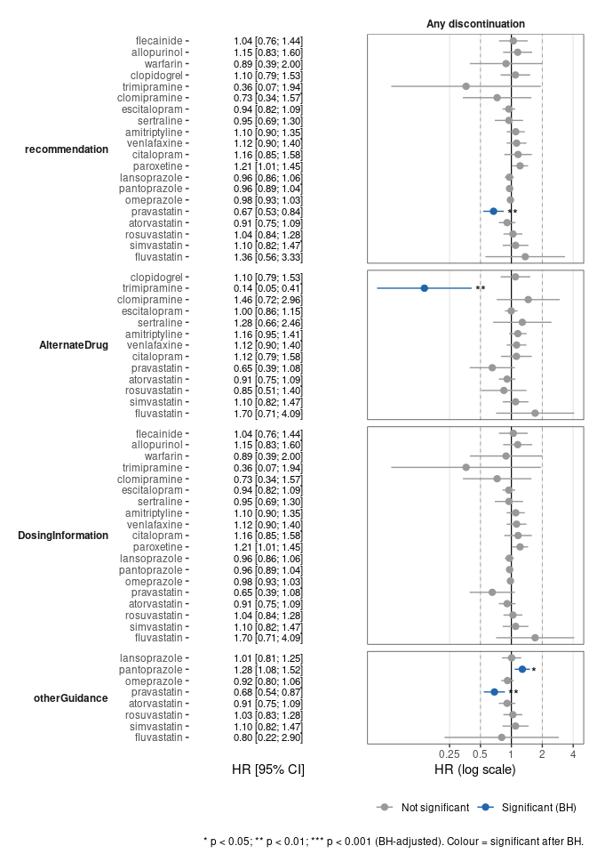

```r
cox_drug_res |>
  dplyr::filter(.data[["is_pgx"]]) |>
  dplyr::filter(.data[["spec"]] == "any_discontinuation") |>
  make_forest(
    y_col = "drug_name",
    facet_row = "pgx_var",
    facet_col = "spec_label",
    order_col = "indication_group",
    x_label = "HR (log scale)",
    ci_label = "HR [95% CI]",
    title = NULL,
    subtitle = NULL
  )
```

**Internal check**: not in the paper

```r
cox_drug_res_gt <- cox_drug_res |>
  dplyr::mutate(
    strata_fmt = dplyr::if_else(
      .data[["in_strata"]] == "", "-", .data[["in_strata"]]
    )
  ) |>
  dplyr::arrange(
    .data[["indication_group"]], .data[["spec_label"]], .data[["pgx_var"]]
  ) |>
  add_significance("p_adj") |>
  dplyr::filter(spec_label == "Any discontinuation") |>
  dplyr::group_by(indication_group, drug_name, pgx_var) |>
  dplyr::filter(any(p_value <= 0.05)) |>
  make_result_gt(
    group_cols = c("indication_group"),
    extra_cols = c(
      "pgx_var", "term", "n_individuals", "n_episodes", "n_event", "strata_fmt"
    ),
    estimate_label = "HR [95% CI]",
    title = NULL,
    subtitle = NULL
  )

cox_drug_res_gt
```

| drug_name | pgx_var | term | n_individuals | n_episodes | n_event | strata_fmt | HR [95% CI] | p | p (BH) |
| --- | --- | --- | --- | --- | --- | --- | --- | --- | --- |
| Lipid-lowering |  |  |  |  |  |  |  |  |  |
| atorvastatin | recommendation | recommendationTRUE | 758 | 1426 | 1048 | - | 0.91 [0.75; 1.09] | 0.313 | 0.653 |
| atorvastatin | recommendation | sexfemale | 758 | 1426 | 1048 | - | 1.21 [1.02; 1.44] | 0.033 | - |
| atorvastatin | recommendation | age_at_episode_start | 758 | 1426 | 1048 | - | 0.98 [0.97; 0.99] | <0.001 | - |
| pravastatin | recommendation | recommendationTRUE | 262 | 767 | 688 | - | 0.67 [0.53; 0.84] | <0.001 | 0.003 |
| pravastatin | recommendation | sexfemale | 262 | 767 | 688 | - | 1.05 [0.85; 1.29] | 0.662 | - |
| pravastatin | recommendation | age_at_episode_start | 262 | 767 | 688 | - | 0.99 [0.98; 1.00] | 0.213 | - |
| simvastatin | recommendation | recommendationTRUE | 254 | 494 | 396 | - | 1.10 [0.82; 1.47] | 0.523 | 0.653 |
| simvastatin | recommendation | sexfemale | 254 | 494 | 396 | - | 1.48 [1.17; 1.88] | 0.001 | - |
| simvastatin | recommendation | age_at_episode_start | 254 | 494 | 396 | - | 0.99 [0.97; 1.00] | 0.135 | - |
| atorvastatin | AlternateDrug | AlternateDrugTRUE | 758 | 1426 | 1048 | - | 0.91 [0.75; 1.09] | 0.313 | 0.522 |
| atorvastatin | AlternateDrug | sexfemale | 758 | 1426 | 1048 | - | 1.21 [1.02; 1.44] | 0.033 | - |
| atorvastatin | AlternateDrug | age_at_episode_start | 758 | 1426 | 1048 | - | 0.98 [0.97; 0.99] | <0.001 | - |
| simvastatin | AlternateDrug | AlternateDrugTRUE | 254 | 494 | 396 | - | 1.10 [0.82; 1.47] | 0.523 | 0.523 |
| simvastatin | AlternateDrug | sexfemale | 254 | 494 | 396 | - | 1.48 [1.17; 1.88] | 0.001 | - |
| simvastatin | AlternateDrug | age_at_episode_start | 254 | 494 | 396 | - | 0.99 [0.97; 1.00] | 0.135 | - |
| atorvastatin | DosingInformation | DosingInformationTRUE | 758 | 1426 | 1048 | - | 0.91 [0.75; 1.09] | 0.313 | 0.522 |
| atorvastatin | DosingInformation | sexfemale | 758 | 1426 | 1048 | - | 1.21 [1.02; 1.44] | 0.033 | - |
| atorvastatin | DosingInformation | age_at_episode_start | 758 | 1426 | 1048 | - | 0.98 [0.97; 0.99] | <0.001 | - |
| simvastatin | DosingInformation | DosingInformationTRUE | 254 | 494 | 396 | - | 1.10 [0.82; 1.47] | 0.523 | 0.653 |
| simvastatin | DosingInformation | sexfemale | 254 | 494 | 396 | - | 1.48 [1.17; 1.88] | 0.001 | - |
| simvastatin | DosingInformation | age_at_episode_start | 254 | 494 | 396 | - | 0.99 [0.97; 1.00] | 0.135 | - |
| atorvastatin | otherGuidance | otherGuidanceTRUE | 758 | 1426 | 1048 | - | 0.91 [0.75; 1.09] | 0.313 | 0.766 |
| atorvastatin | otherGuidance | sexfemale | 758 | 1426 | 1048 | - | 1.21 [1.02; 1.44] | 0.033 | - |
| atorvastatin | otherGuidance | age_at_episode_start | 758 | 1426 | 1048 | - | 0.98 [0.97; 0.99] | <0.001 | - |
| pravastatin | otherGuidance | otherGuidanceTRUE | 262 | 767 | 688 | - | 0.68 [0.54; 0.87] | 0.002 | 0.008 |
| pravastatin | otherGuidance | sexfemale | 262 | 767 | 688 | - | 1.04 [0.84; 1.28] | 0.744 | - |
| pravastatin | otherGuidance | age_at_episode_start | 262 | 767 | 688 | - | 0.99 [0.98; 1.01] | 0.224 | - |
| simvastatin | otherGuidance | otherGuidanceTRUE | 254 | 494 | 396 | - | 1.10 [0.82; 1.47] | 0.537 | 0.766 |
| simvastatin | otherGuidance | sexfemale | 254 | 494 | 396 | - | 1.48 [1.17; 1.88] | 0.001 | - |
| simvastatin | otherGuidance | age_at_episode_start | 254 | 494 | 396 | - | 0.99 [0.97; 1.00] | 0.134 | - |
| Acid suppression |  |  |  |  |  |  |  |  |  |
| omeprazole | recommendation | recommendationTRUE | 3822 | 8128 | 7752 | - | 0.98 [0.93; 1.03] | 0.439 | 0.439 |
| omeprazole | recommendation | sexfemale | 3822 | 8128 | 7752 | - | 0.93 [0.89; 0.98] | 0.008 | - |
| omeprazole | recommendation | age_at_episode_start | 3822 | 8128 | 7752 | - | 0.99 [0.99; 0.99] | <0.001 | - |
| pantoprazole | recommendation | recommendationTRUE | 2227 | 3614 | 3387 | - | 0.96 [0.89; 1.04] | 0.309 | 0.439 |
| pantoprazole | recommendation | sexfemale | 2227 | 3614 | 3387 | - | 1.04 [0.96; 1.12] | 0.346 | - |
| pantoprazole | recommendation | age_at_episode_start | 2227 | 3614 | 3387 | - | 0.98 [0.98; 0.99] | <0.001 | - |
| omeprazole | DosingInformation | DosingInformationTRUE | 3822 | 8128 | 7752 | - | 0.98 [0.93; 1.03] | 0.439 | 0.439 |
| omeprazole | DosingInformation | sexfemale | 3822 | 8128 | 7752 | - | 0.93 [0.89; 0.98] | 0.008 | - |
| omeprazole | DosingInformation | age_at_episode_start | 3822 | 8128 | 7752 | - | 0.99 [0.99; 0.99] | <0.001 | - |
| pantoprazole | DosingInformation | DosingInformationTRUE | 2227 | 3614 | 3387 | - | 0.96 [0.89; 1.04] | 0.309 | 0.439 |
| pantoprazole | DosingInformation | sexfemale | 2227 | 3614 | 3387 | - | 1.04 [0.96; 1.12] | 0.346 | - |
| pantoprazole | DosingInformation | age_at_episode_start | 2227 | 3614 | 3387 | - | 0.98 [0.98; 0.99] | <0.001 | - |
| omeprazole | otherGuidance | otherGuidanceTRUE | 3822 | 8128 | 7752 | - | 0.92 [0.80; 1.06] | 0.225 | 0.337 |
| omeprazole | otherGuidance | sexfemale | 3822 | 8128 | 7752 | - | 0.93 [0.89; 0.98] | 0.008 | - |
| omeprazole | otherGuidance | age_at_episode_start | 3822 | 8128 | 7752 | - | 0.99 [0.99; 0.99] | <0.001 | - |
| pantoprazole | otherGuidance | otherGuidanceTRUE | 2227 | 3614 | 3387 | - | 1.28 [1.08; 1.52] | 0.005 | 0.014 |
| pantoprazole | otherGuidance | sexfemale | 2227 | 3614 | 3387 | - | 1.04 [0.96; 1.12] | 0.336 | - |
| pantoprazole | otherGuidance | age_at_episode_start | 2227 | 3614 | 3387 | - | 0.98 [0.98; 0.99] | <0.001 | - |
| Antidepressant |  |  |  |  |  |  |  |  |  |
| escitalopram | recommendation | recommendationTRUE | 717 | 1255 | 1175 | - | 0.94 [0.82; 1.09] | 0.429 | 0.491 |
| escitalopram | recommendation | sexfemale | 717 | 1255 | 1175 | - | 0.82 [0.71; 0.95] | 0.008 | - |
| escitalopram | recommendation | age_at_episode_start | 717 | 1255 | 1175 | - | 0.99 [0.99; 1.00] | 0.059 | - |
| paroxetine | recommendation | recommendationTRUE | 443 | 716 | 651 | age_at_episode_start | 1.21 [1.01; 1.45] | 0.034 | 0.276 |
| paroxetine | recommendation | sexfemale | 443 | 716 | 651 | age_at_episode_start | 0.83 [0.69; 1.00] | 0.048 | - |
| escitalopram | AlternateDrug | AlternateDrugTRUE | 717 | 1255 | 1175 | - | 1.00 [0.86; 1.15] | 0.963 | 0.963 |
| escitalopram | AlternateDrug | sexfemale | 717 | 1255 | 1175 | - | 0.82 [0.71; 0.95] | 0.008 | - |
| escitalopram | AlternateDrug | age_at_episode_start | 717 | 1255 | 1175 | - | 0.99 [0.99; 1.00] | 0.059 | - |
| trimipramine | AlternateDrug | AlternateDrugTRUE | 9 | 10 | 10 | - | 0.14 [0.05; 0.41] | <0.001 | 0.002 |
| trimipramine | AlternateDrug | sexfemale | 9 | 10 | 10 | - | 0.24 [0.08; 0.71] | 0.010 | - |
| trimipramine | AlternateDrug | age_at_episode_start | 9 | 10 | 10 | - | 1.00 [0.94; 1.06] | 0.948 | - |
| escitalopram | DosingInformation | DosingInformationTRUE | 717 | 1255 | 1175 | - | 0.94 [0.82; 1.09] | 0.429 | 0.491 |
| escitalopram | DosingInformation | sexfemale | 717 | 1255 | 1175 | - | 0.82 [0.71; 0.95] | 0.008 | - |
| escitalopram | DosingInformation | age_at_episode_start | 717 | 1255 | 1175 | - | 0.99 [0.99; 1.00] | 0.059 | - |
| paroxetine | DosingInformation | DosingInformationTRUE | 443 | 716 | 651 | age_at_episode_start | 1.21 [1.01; 1.45] | 0.034 | 0.276 |
| paroxetine | DosingInformation | sexfemale | 443 | 716 | 651 | age_at_episode_start | 0.83 [0.69; 1.00] | 0.048 | - |
| Gout |  |  |  |  |  |  |  |  |  |
| allopurinol | recommendation | recommendationTRUE | 152 | 299 | 243 | - | 1.15 [0.83; 1.60] | 0.396 | 0.396 |
| allopurinol | recommendation | sexfemale | 152 | 299 | 243 | - | 1.52 [1.01; 2.27] | 0.042 | - |
| allopurinol | recommendation | age_at_episode_start | 152 | 299 | 243 | - | 0.98 [0.96; 1.00] | 0.111 | - |
| allopurinol | DosingInformation | DosingInformationTRUE | 152 | 299 | 243 | - | 1.15 [0.83; 1.60] | 0.396 | 0.396 |
| allopurinol | DosingInformation | sexfemale | 152 | 299 | 243 | - | 1.52 [1.01; 2.27] | 0.042 | - |
| allopurinol | DosingInformation | age_at_episode_start | 152 | 299 | 243 | - | 0.98 [0.96; 1.00] | 0.111 | - |

**LaTeX source**

````r
cat("```latex\n", gt::as_latex(cox_drug_res_gt), "\n```\n", sep="")
````

```latex
\begin{table}
\fontsize{7.5pt}{9.0pt}\selectfont
\begin{tabular*}{\linewidth}{@{\extracolsep{\fill}}lclrrrlllr}
\toprule
drug\_name & pgx\_var & term & n\_individuals & n\_episodes & n\_event & strata\_fmt & HR [95\% CI] & p & p (BH) \\
\midrule\addlinespace[2.5pt]
\multicolumn{10}{l}{{\bfseries Lipid-lowering}} \\[2.5pt]
\midrule\addlinespace[2.5pt]
atorvastatin & recommendation & recommendationTRUE & 758 & 1426 & 1048 & - & 0.91 [0.75; 1.09] & 0.313 & 0.653 \\
atorvastatin & recommendation & sexfemale & 758 & 1426 & 1048 & - & 1.21 [1.02; 1.44] & 0.033 & - \\
atorvastatin & recommendation & age\_at\_episode\_start & 758 & 1426 & 1048 & - & 0.98 [0.97; 0.99] & <0.001 & - \\
pravastatin & recommendation & recommendationTRUE & 262 & 767 & 688 & - & 0.67 [0.53; 0.84] & <0.001 & 0.003 \\
pravastatin & recommendation & sexfemale & 262 & 767 & 688 & - & 1.05 [0.85; 1.29] & 0.662 & - \\
pravastatin & recommendation & age\_at\_episode\_start & 262 & 767 & 688 & - & 0.99 [0.98; 1.00] & 0.213 & - \\
simvastatin & recommendation & recommendationTRUE & 254 & 494 & 396 & - & 1.10 [0.82; 1.47] & 0.523 & 0.653 \\
simvastatin & recommendation & sexfemale & 254 & 494 & 396 & - & 1.48 [1.17; 1.88] & 0.001 & - \\
simvastatin & recommendation & age\_at\_episode\_start & 254 & 494 & 396 & - & 0.99 [0.97; 1.00] & 0.135 & - \\
atorvastatin & AlternateDrug & AlternateDrugTRUE & 758 & 1426 & 1048 & - & 0.91 [0.75; 1.09] & 0.313 & 0.522 \\
atorvastatin & AlternateDrug & sexfemale & 758 & 1426 & 1048 & - & 1.21 [1.02; 1.44] & 0.033 & - \\
atorvastatin & AlternateDrug & age\_at\_episode\_start & 758 & 1426 & 1048 & - & 0.98 [0.97; 0.99] & <0.001 & - \\
simvastatin & AlternateDrug & AlternateDrugTRUE & 254 & 494 & 396 & - & 1.10 [0.82; 1.47] & 0.523 & 0.523 \\
simvastatin & AlternateDrug & sexfemale & 254 & 494 & 396 & - & 1.48 [1.17; 1.88] & 0.001 & - \\
simvastatin & AlternateDrug & age\_at\_episode\_start & 254 & 494 & 396 & - & 0.99 [0.97; 1.00] & 0.135 & - \\
atorvastatin & DosingInformation & DosingInformationTRUE & 758 & 1426 & 1048 & - & 0.91 [0.75; 1.09] & 0.313 & 0.522 \\
atorvastatin & DosingInformation & sexfemale & 758 & 1426 & 1048 & - & 1.21 [1.02; 1.44] & 0.033 & - \\
atorvastatin & DosingInformation & age\_at\_episode\_start & 758 & 1426 & 1048 & - & 0.98 [0.97; 0.99] & <0.001 & - \\
simvastatin & DosingInformation & DosingInformationTRUE & 254 & 494 & 396 & - & 1.10 [0.82; 1.47] & 0.523 & 0.653 \\
simvastatin & DosingInformation & sexfemale & 254 & 494 & 396 & - & 1.48 [1.17; 1.88] & 0.001 & - \\
simvastatin & DosingInformation & age\_at\_episode\_start & 254 & 494 & 396 & - & 0.99 [0.97; 1.00] & 0.135 & - \\
atorvastatin & otherGuidance & otherGuidanceTRUE & 758 & 1426 & 1048 & - & 0.91 [0.75; 1.09] & 0.313 & 0.766 \\
atorvastatin & otherGuidance & sexfemale & 758 & 1426 & 1048 & - & 1.21 [1.02; 1.44] & 0.033 & - \\
atorvastatin & otherGuidance & age\_at\_episode\_start & 758 & 1426 & 1048 & - & 0.98 [0.97; 0.99] & <0.001 & - \\
pravastatin & otherGuidance & otherGuidanceTRUE & 262 & 767 & 688 & - & 0.68 [0.54; 0.87] & 0.002 & 0.008 \\
pravastatin & otherGuidance & sexfemale & 262 & 767 & 688 & - & 1.04 [0.84; 1.28] & 0.744 & - \\
pravastatin & otherGuidance & age\_at\_episode\_start & 262 & 767 & 688 & - & 0.99 [0.98; 1.01] & 0.224 & - \\
simvastatin & otherGuidance & otherGuidanceTRUE & 254 & 494 & 396 & - & 1.10 [0.82; 1.47] & 0.537 & 0.766 \\
simvastatin & otherGuidance & sexfemale & 254 & 494 & 396 & - & 1.48 [1.17; 1.88] & 0.001 & - \\
simvastatin & otherGuidance & age\_at\_episode\_start & 254 & 494 & 396 & - & 0.99 [0.97; 1.00] & 0.134 & - \\
\midrule\addlinespace[2.5pt]
\multicolumn{10}{l}{{\bfseries Acid suppression}} \\[2.5pt]
\midrule\addlinespace[2.5pt]
omeprazole & recommendation & recommendationTRUE & 3822 & 8128 & 7752 & - & 0.98 [0.93; 1.03] & 0.439 & 0.439 \\
omeprazole & recommendation & sexfemale & 3822 & 8128 & 7752 & - & 0.93 [0.89; 0.98] & 0.008 & - \\
omeprazole & recommendation & age\_at\_episode\_start & 3822 & 8128 & 7752 & - & 0.99 [0.99; 0.99] & <0.001 & - \\
pantoprazole & recommendation & recommendationTRUE & 2227 & 3614 & 3387 & - & 0.96 [0.89; 1.04] & 0.309 & 0.439 \\
pantoprazole & recommendation & sexfemale & 2227 & 3614 & 3387 & - & 1.04 [0.96; 1.12] & 0.346 & - \\
pantoprazole & recommendation & age\_at\_episode\_start & 2227 & 3614 & 3387 & - & 0.98 [0.98; 0.99] & <0.001 & - \\
omeprazole & DosingInformation & DosingInformationTRUE & 3822 & 8128 & 7752 & - & 0.98 [0.93; 1.03] & 0.439 & 0.439 \\
omeprazole & DosingInformation & sexfemale & 3822 & 8128 & 7752 & - & 0.93 [0.89; 0.98] & 0.008 & - \\
omeprazole & DosingInformation & age\_at\_episode\_start & 3822 & 8128 & 7752 & - & 0.99 [0.99; 0.99] & <0.001 & - \\
pantoprazole & DosingInformation & DosingInformationTRUE & 2227 & 3614 & 3387 & - & 0.96 [0.89; 1.04] & 0.309 & 0.439 \\
pantoprazole & DosingInformation & sexfemale & 2227 & 3614 & 3387 & - & 1.04 [0.96; 1.12] & 0.346 & - \\
pantoprazole & DosingInformation & age\_at\_episode\_start & 2227 & 3614 & 3387 & - & 0.98 [0.98; 0.99] & <0.001 & - \\
omeprazole & otherGuidance & otherGuidanceTRUE & 3822 & 8128 & 7752 & - & 0.92 [0.80; 1.06] & 0.225 & 0.337 \\
omeprazole & otherGuidance & sexfemale & 3822 & 8128 & 7752 & - & 0.93 [0.89; 0.98] & 0.008 & - \\
omeprazole & otherGuidance & age\_at\_episode\_start & 3822 & 8128 & 7752 & - & 0.99 [0.99; 0.99] & <0.001 & - \\
pantoprazole & otherGuidance & otherGuidanceTRUE & 2227 & 3614 & 3387 & - & 1.28 [1.08; 1.52] & 0.005 & 0.014 \\
pantoprazole & otherGuidance & sexfemale & 2227 & 3614 & 3387 & - & 1.04 [0.96; 1.12] & 0.336 & - \\
pantoprazole & otherGuidance & age\_at\_episode\_start & 2227 & 3614 & 3387 & - & 0.98 [0.98; 0.99] & <0.001 & - \\
\midrule\addlinespace[2.5pt]
\multicolumn{10}{l}{{\bfseries Antidepressant}} \\[2.5pt]
\midrule\addlinespace[2.5pt]
escitalopram & recommendation & recommendationTRUE & 717 & 1255 & 1175 & - & 0.94 [0.82; 1.09] & 0.429 & 0.491 \\
escitalopram & recommendation & sexfemale & 717 & 1255 & 1175 & - & 0.82 [0.71; 0.95] & 0.008 & - \\
escitalopram & recommendation & age\_at\_episode\_start & 717 & 1255 & 1175 & - & 0.99 [0.99; 1.00] & 0.059 & - \\
paroxetine & recommendation & recommendationTRUE & 443 & 716 & 651 & age\_at\_episode\_start & 1.21 [1.01; 1.45] & 0.034 & 0.276 \\
paroxetine & recommendation & sexfemale & 443 & 716 & 651 & age\_at\_episode\_start & 0.83 [0.69; 1.00] & 0.048 & - \\
escitalopram & AlternateDrug & AlternateDrugTRUE & 717 & 1255 & 1175 & - & 1.00 [0.86; 1.15] & 0.963 & 0.963 \\
escitalopram & AlternateDrug & sexfemale & 717 & 1255 & 1175 & - & 0.82 [0.71; 0.95] & 0.008 & - \\
escitalopram & AlternateDrug & age\_at\_episode\_start & 717 & 1255 & 1175 & - & 0.99 [0.99; 1.00] & 0.059 & - \\
trimipramine & AlternateDrug & AlternateDrugTRUE & 9 & 10 & 10 & - & 0.14 [0.05; 0.41] & <0.001 & 0.002 \\
trimipramine & AlternateDrug & sexfemale & 9 & 10 & 10 & - & 0.24 [0.08; 0.71] & 0.010 & - \\
trimipramine & AlternateDrug & age\_at\_episode\_start & 9 & 10 & 10 & - & 1.00 [0.94; 1.06] & 0.948 & - \\
escitalopram & DosingInformation & DosingInformationTRUE & 717 & 1255 & 1175 & - & 0.94 [0.82; 1.09] & 0.429 & 0.491 \\
escitalopram & DosingInformation & sexfemale & 717 & 1255 & 1175 & - & 0.82 [0.71; 0.95] & 0.008 & - \\
escitalopram & DosingInformation & age\_at\_episode\_start & 717 & 1255 & 1175 & - & 0.99 [0.99; 1.00] & 0.059 & - \\
paroxetine & DosingInformation & DosingInformationTRUE & 443 & 716 & 651 & age\_at\_episode\_start & 1.21 [1.01; 1.45] & 0.034 & 0.276 \\
paroxetine & DosingInformation & sexfemale & 443 & 716 & 651 & age\_at\_episode\_start & 0.83 [0.69; 1.00] & 0.048 & - \\
\midrule\addlinespace[2.5pt]
\multicolumn{10}{l}{{\bfseries Gout}} \\[2.5pt]
\midrule\addlinespace[2.5pt]
allopurinol & recommendation & recommendationTRUE & 152 & 299 & 243 & - & 1.15 [0.83; 1.60] & 0.396 & 0.396 \\
allopurinol & recommendation & sexfemale & 152 & 299 & 243 & - & 1.52 [1.01; 2.27] & 0.042 & - \\
allopurinol & recommendation & age\_at\_episode\_start & 152 & 299 & 243 & - & 0.98 [0.96; 1.00] & 0.111 & - \\
allopurinol & DosingInformation & DosingInformationTRUE & 152 & 299 & 243 & - & 1.15 [0.83; 1.60] & 0.396 & 0.396 \\
allopurinol & DosingInformation & sexfemale & 152 & 299 & 243 & - & 1.52 [1.01; 2.27] & 0.042 & - \\
allopurinol & DosingInformation & age\_at\_episode\_start & 152 & 299 & 243 & - & 0.98 [0.96; 1.00] & 0.111 & - \\
\bottomrule
\end{tabular*}
\end{table}
```

**Internal check**: per-drug survival curves, not in the paper

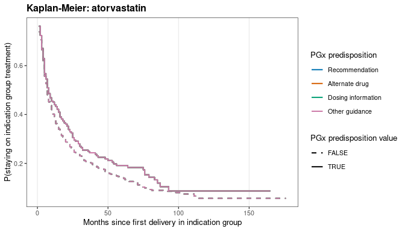

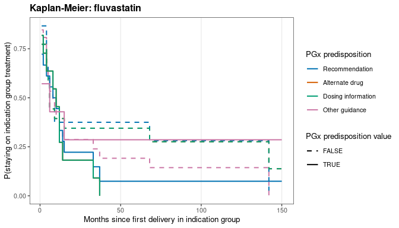

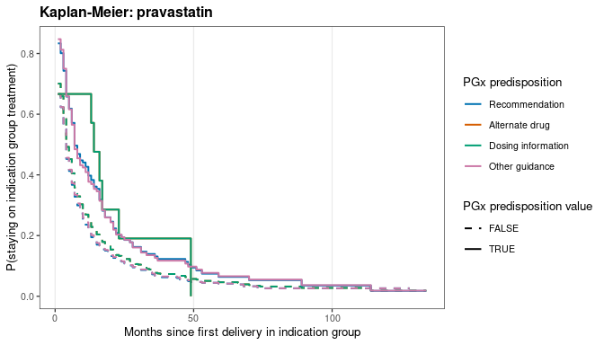

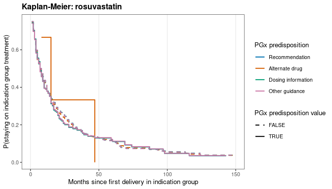

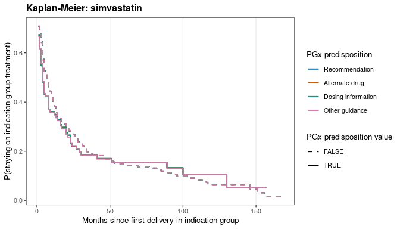

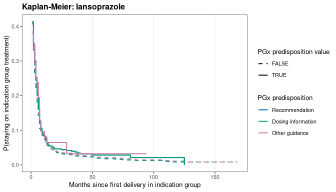

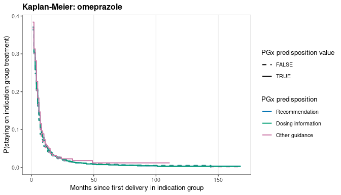

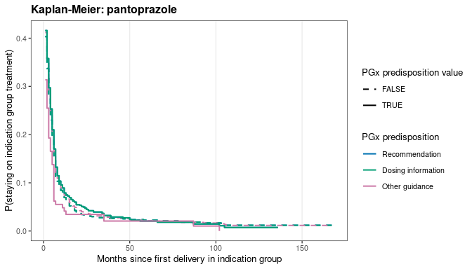

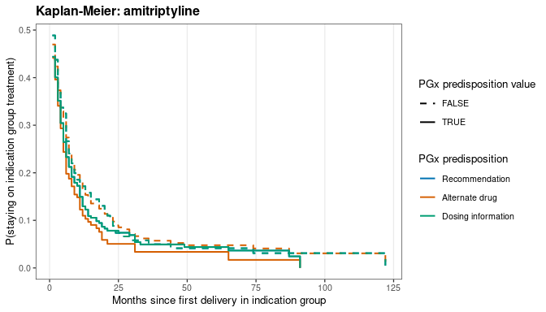

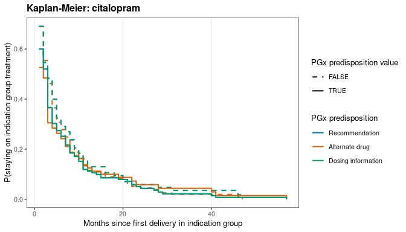

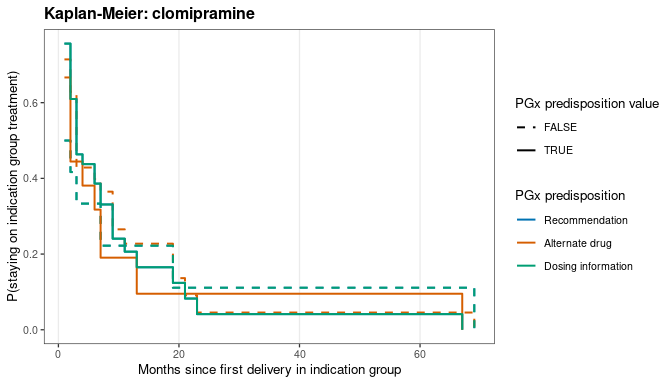

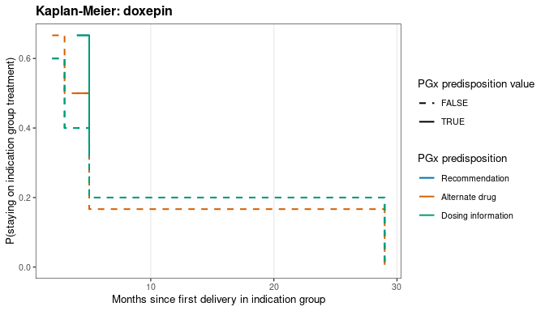

[11 more figures not shown]

```r
km_drug <- treatment_episodes |>
  dplyr::group_by(drug_name, atc3, indication_group) |>
  dplyr::group_split() |>
  purrr::map(\(df_drug) {
    res <- km_build(df_drug)
    if (nrow(res) == 0L) {
      return(NULL)
    }
    dplyr::mutate(
      res,
      drug_name = dplyr::first(df_drug[["drug_name"]]),
      indication_group = dplyr::first(df_drug[["indication_group"]])
    )
  }) |>
  purrr::list_rbind()

purrr::walk(refill_windows[["drug_name"]], \(drug) {
  sub <- dplyr::filter(km_drug, drug_name == drug)
  if (nrow(sub) == 0L) {
    return(invisible(NULL))
  }
  p <- sub |>
    dplyr::mutate(pgx_var = factor(.data[["pgx_var"]], levels = pgx_variables)) |>
    ggplot2::ggplot(ggplot2::aes(
      x = .data[["time"]],
      y = .data[["surv"]],
      colour = .data[["pgx_var"]],
      linetype = .data[["pgx_value"]],
      group = interaction(.data[["pgx_var"]], .data[["pgx_value"]])
    )) +
    ggplot2::geom_step(linewidth = 0.7) +
    ggplot2::scale_linetype_manual(values = c(`TRUE` = "solid", `FALSE` = "dashed")) +
    ggplot2::scale_colour_manual(values = pgx_var_colours, labels = pgx_labels) +
    ggplot2::labs(
      x = "Months since first delivery in indication group",
      y = "P(staying on indication group treatment)",
      colour = "PGx predisposition",
      linetype = "PGx predisposition value",
      title = sprintf("Kaplan-Meier: %s", drug)
    ) +
    theme_pgx(base_size = 10) +
    ggplot2::theme(legend.position = "right")
  print(p)
})
```

# Supplementary: dispensing intensity

A different question from the two above: not *whether* someone stops, but how intensively they are dispensed while they are on the drug. The outcome is the total number of boxes over the individual’s observation time, with `log(person_years)` as an offset so the coefficient reads as a rate: boxes per person-year (rather than a total).

We use a negative binomial absorbs the box count overdispersion. The exponentiated PGx coefficient is a rate ratio, adjusted for sex and age.

Person-time runs from the individual’s first dispensing of the drug to the end of follow-up: it is not trimmed at their last dispensing, so someone who stopped early counts their post-stop time as low-intensity exposure rather than dropping out.

```r
dispensing_counts <- dplyr::left_join(
  x = cohort,
  y = dispensings,
  by = c("individual_id", "drug_name", "atc3")
) |>
  dplyr::transmute(
    individual_id,
    drug_name,
    atc3,
    indication_group,
    sex,
    age_first,
    dplyr::across(dplyr::all_of(pgx_variables)),
    first_dispensing,
    person_years = as.numeric(followup_end - .data[["first_dispensing"]]) / 365.25,
    box_count
  ) |>
  dplyr::summarise(
    n_boxes = sum(.data[["box_count"]]),
    .by = c(
      "individual_id",
      "drug_name",
      "atc3",
      "indication_group",
      "sex",
      "age_first",
      "person_years",
      dplyr::all_of(pgx_variables)
    )
  )
```

```r
fit_negbin_one <- function(df, drug_name, pgx_var) {
  sub <- dplyr::filter(
    df, drug_name == .env[["drug_name"]], !is.na(.data[[pgx_var]])
  )
  # Is there enough contrast in the exposure, and enough data to fit a model?
  if (dplyr::n_distinct(stats::na.omit(sub[[pgx_var]])) < 2L || nrow(sub) < 30L) {
    return(NULL)
  }
  fit <- tryCatch(
    MASS::glm.nb(
      stats::reformulate(
        c(pgx_var, "sex", "age_first", "offset(log(person_years))"), "n_boxes"
      ),
      data = sub
    ),
    error = \(e) NULL
  )
  if (is.null(fit)) {
    return(NULL)
  }
  coefs <- summary(fit)[["coefficients"]]
  if (any(coefs[, "Std. Error"] > 10, na.rm = TRUE)) {
    return(NULL)
  }
  purrr::map(rownames(coefs)[-1], \(pred) {
    b <- coefs[pred, "Estimate"]
    se <- coefs[pred, "Std. Error"]
    tibble::tibble(
      drug_name = drug_name,
      pgx_var = pgx_var,
      predictor = pred,
      estimate = exp(b),
      lo = exp(b - 1.96 * se),
      hi = exp(b + 1.96 * se),
      p_value = coefs[pred, "Pr(>|z|)"],
      n = nrow(sub)
    )
  }) |>
    purrr::list_rbind()
}

negbin_res <- purrr::pmap(
  model_grid,
  \(drug_name, pgx_var) fit_negbin_one(dispensing_counts, drug_name, pgx_var)
) |>
  purrr::list_rbind() |>
  dplyr::inner_join(
    dplyr::distinct(drug_indication_map, drug_name, indication_group),
    by = "drug_name"
  ) |>
  dplyr::mutate(
    coef_type = classify_coef(.data[["predictor"]]),
    is_pgx = .data[["coef_type"]] == "PGx (interest)",
    pgx_var = factor(.data[["pgx_var"]], levels = pgx_variables),
    indication_group = factor(.data[["indication_group"]], levels = indication_levels)
  ) |>
  dplyr::group_by(.data[["indication_group"]], .data[["pgx_var"]]) |>
  dplyr::mutate(p_adj = bh_within(.data[["p_value"]], .data[["is_pgx"]])) |>
  dplyr::ungroup()
```

**Paper output**: Figure `\ref{fig:negative-binom}` (`figures/negative-binom.png`)

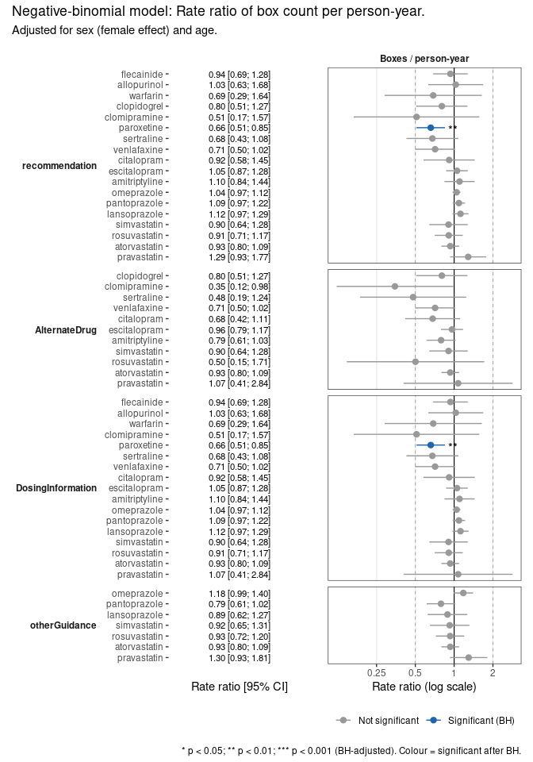

```r
negbin_res |>
  dplyr::filter(.data[["is_pgx"]]) |>
  dplyr::mutate(panel_label = "Boxes / person-year") |>
  make_forest(
    y_col = "drug_name",
    facet_row = "pgx_var",
    facet_col = "panel_label",
    order_col = "indication_group",
    colour_col = "indication_group",
    x_label = "Rate ratio (log scale)",
    ci_label = "Rate ratio [95% CI]",
    title = "Negative-binomial model: Rate ratio of box count per person-year.",
    subtitle = "Adjusted for sex (female effect) and age."
  )
```

**Internal check** : full coefficient table, not in the paper.

```r
negbin_res_gt <- negbin_res |>
  dplyr::arrange(
    .data[["indication_group"]], .data[["drug_name"]], .data[["pgx_var"]]
  ) |>
  add_significance("p_adj") |>
  dplyr::group_by(dplyr::across(dplyr::all_of(c(
    "indication_group", "drug_name", "pgx_var"
  )))) |>
  make_result_gt(
    group_cols = c("indication_group", "drug_name"),
    extra_cols = c("pgx_var", "predictor", "n"),
    estimate_label = "Rate ratio [95% CI]",
    title = "Negative-binomial model: PGx coefficients",
    subtitle = "Box count per person-year. BH within indication x PGx predisposition."
  )

negbin_res_gt
```

Negative-binomial model: PGx coefficients

Box count per person-year. BH within indication x PGx predisposition.

| pgx_var | predictor | n | Rate ratio [95% CI] | p | p (BH) |
| --- | --- | --- | --- | --- | --- |
| Lipid-lowering - atorvastatin |  |  |  |  |  |
| recommendation | recommendationTRUE | 758 | 0.93 [0.80; 1.09] | 0.394 | 0.568 |
| recommendation | sexfemale | 758 | 0.82 [0.71; 0.94] | 0.006 | - |
| recommendation | age_first | 758 | 1.04 [1.03; 1.05] | <0.001 | - |
| AlternateDrug | AlternateDrugTRUE | 758 | 0.93 [0.80; 1.09] | 0.394 | 0.757 |
| AlternateDrug | sexfemale | 758 | 0.82 [0.71; 0.94] | 0.006 | - |
| AlternateDrug | age_first | 758 | 1.04 [1.03; 1.05] | <0.001 | - |
| DosingInformation | DosingInformationTRUE | 758 | 0.93 [0.80; 1.09] | 0.394 | 0.757 |
| DosingInformation | sexfemale | 758 | 0.82 [0.71; 0.94] | 0.006 | - |
| DosingInformation | age_first | 758 | 1.04 [1.03; 1.05] | <0.001 | - |
| otherGuidance | otherGuidanceTRUE | 758 | 0.93 [0.80; 1.09] | 0.394 | 0.662 |
| otherGuidance | sexfemale | 758 | 0.82 [0.71; 0.94] | 0.006 | - |
| otherGuidance | age_first | 758 | 1.04 [1.03; 1.05] | <0.001 | - |
| Lipid-lowering - pravastatin |  |  |  |  |  |
| recommendation | recommendationTRUE | 262 | 1.29 [0.93; 1.77] | 0.127 | 0.507 |
| recommendation | sexfemale | 262 | 0.98 [0.74; 1.29] | 0.875 | - |
| recommendation | age_first | 262 | 1.03 [1.01; 1.04] | 0.001 | - |
| AlternateDrug | AlternateDrugTRUE | 262 | 1.07 [0.41; 2.84] | 0.887 | 0.887 |
| AlternateDrug | sexfemale | 262 | 0.95 [0.72; 1.25] | 0.696 | - |
| AlternateDrug | age_first | 262 | 1.03 [1.01; 1.04] | 0.001 | - |
| DosingInformation | DosingInformationTRUE | 262 | 1.07 [0.41; 2.84] | 0.887 | 0.887 |
| DosingInformation | sexfemale | 262 | 0.95 [0.72; 1.25] | 0.696 | - |
| DosingInformation | age_first | 262 | 1.03 [1.01; 1.04] | 0.001 | - |
| otherGuidance | otherGuidanceTRUE | 262 | 1.30 [0.93; 1.81] | 0.126 | 0.504 |
| otherGuidance | sexfemale | 262 | 0.99 [0.75; 1.30] | 0.926 | - |
| otherGuidance | age_first | 262 | 1.03 [1.01; 1.04] | 0.001 | - |
| Lipid-lowering - rosuvastatin |  |  |  |  |  |
| recommendation | recommendationTRUE | 367 | 0.91 [0.71; 1.17] | 0.452 | 0.568 |
| recommendation | sexfemale | 367 | 0.91 [0.73; 1.15] | 0.431 | - |
| recommendation | age_first | 367 | 1.02 [1.01; 1.04] | 0.001 | - |

[output cut: 147 more lines]

**LaTeX source**

````r
cat("```latex\n", gt::as_latex(negbin_res_gt), "\n```\n", sep="")
````

```latex
\begin{table}
\caption*{
{\large Negative-binomial model: PGx coefficients} \\
{\small Box count per person-year. BH within indication x PGx predisposition.}
}
\fontsize{7.5pt}{9.0pt}\selectfont
\begin{tabular*}{\linewidth}{@{\extracolsep{\fill}}clrllr}
\toprule
pgx\_var & predictor & n & Rate ratio [95\% CI] & p & p (BH) \\
\midrule\addlinespace[2.5pt]
\multicolumn{6}{l}{{\bfseries Lipid-lowering - atorvastatin}} \\[2.5pt]
\midrule\addlinespace[2.5pt]
recommendation & recommendationTRUE & 758 & 0.93 [0.80; 1.09] & 0.394 & 0.568 \\
recommendation & sexfemale & 758 & 0.82 [0.71; 0.94] & 0.006 & - \\
recommendation & age\_first & 758 & 1.04 [1.03; 1.05] & <0.001 & - \\
AlternateDrug & AlternateDrugTRUE & 758 & 0.93 [0.80; 1.09] & 0.394 & 0.757 \\
AlternateDrug & sexfemale & 758 & 0.82 [0.71; 0.94] & 0.006 & - \\
AlternateDrug & age\_first & 758 & 1.04 [1.03; 1.05] & <0.001 & - \\
DosingInformation & DosingInformationTRUE & 758 & 0.93 [0.80; 1.09] & 0.394 & 0.757 \\
DosingInformation & sexfemale & 758 & 0.82 [0.71; 0.94] & 0.006 & - \\
DosingInformation & age\_first & 758 & 1.04 [1.03; 1.05] & <0.001 & - \\
otherGuidance & otherGuidanceTRUE & 758 & 0.93 [0.80; 1.09] & 0.394 & 0.662 \\
otherGuidance & sexfemale & 758 & 0.82 [0.71; 0.94] & 0.006 & - \\
otherGuidance & age\_first & 758 & 1.04 [1.03; 1.05] & <0.001 & - \\
\midrule\addlinespace[2.5pt]
\multicolumn{6}{l}{{\bfseries Lipid-lowering - pravastatin}} \\[2.5pt]
\midrule\addlinespace[2.5pt]
recommendation & recommendationTRUE & 262 & 1.29 [0.93; 1.77] & 0.127 & 0.507 \\
recommendation & sexfemale & 262 & 0.98 [0.74; 1.29] & 0.875 & - \\
recommendation & age\_first & 262 & 1.03 [1.01; 1.04] & 0.001 & - \\
AlternateDrug & AlternateDrugTRUE & 262 & 1.07 [0.41; 2.84] & 0.887 & 0.887 \\
AlternateDrug & sexfemale & 262 & 0.95 [0.72; 1.25] & 0.696 & - \\
AlternateDrug & age\_first & 262 & 1.03 [1.01; 1.04] & 0.001 & - \\
DosingInformation & DosingInformationTRUE & 262 & 1.07 [0.41; 2.84] & 0.887 & 0.887 \\
DosingInformation & sexfemale & 262 & 0.95 [0.72; 1.25] & 0.696 & - \\
DosingInformation & age\_first & 262 & 1.03 [1.01; 1.04] & 0.001 & - \\
otherGuidance & otherGuidanceTRUE & 262 & 1.30 [0.93; 1.81] & 0.126 & 0.504 \\
otherGuidance & sexfemale & 262 & 0.99 [0.75; 1.30] & 0.926 & - \\
otherGuidance & age\_first & 262 & 1.03 [1.01; 1.04] & 0.001 & - \\
\midrule\addlinespace[2.5pt]
\multicolumn{6}{l}{{\bfseries Lipid-lowering - rosuvastatin}} \\[2.5pt]
\midrule\addlinespace[2.5pt]
recommendation & recommendationTRUE & 367 & 0.91 [0.71; 1.17] & 0.452 & 0.568 \\
recommendation & sexfemale & 367 & 0.91 [0.73; 1.15] & 0.431 & - \\
recommendation & age\_first & 367 & 1.02 [1.01; 1.04] & 0.001 & - \\
AlternateDrug & AlternateDrugTRUE & 367 & 0.50 [0.15; 1.71] & 0.271 & 0.757 \\
AlternateDrug & sexfemale & 367 & 0.91 [0.72; 1.14] & 0.411 & - \\
AlternateDrug & age\_first & 367 & 1.02 [1.01; 1.04] & <0.001 & - \\
DosingInformation & DosingInformationTRUE & 367 & 0.91 [0.71; 1.17] & 0.452 & 0.757 \\
DosingInformation & sexfemale & 367 & 0.91 [0.73; 1.15] & 0.431 & - \\
DosingInformation & age\_first & 367 & 1.02 [1.01; 1.04] & 0.001 & - \\
otherGuidance & otherGuidanceTRUE & 367 & 0.93 [0.72; 1.20] & 0.577 & 0.662 \\
otherGuidance & sexfemale & 367 & 0.91 [0.73; 1.15] & 0.437 & - \\
otherGuidance & age\_first & 367 & 1.02 [1.01; 1.04] & 0.001 & - \\
\midrule\addlinespace[2.5pt]
\multicolumn{6}{l}{{\bfseries Lipid-lowering - simvastatin}} \\[2.5pt]
\midrule\addlinespace[2.5pt]
recommendation & recommendationTRUE & 254 & 0.90 [0.64; 1.28] & 0.568 & 0.568 \\
recommendation & sexfemale & 254 & 0.92 [0.68; 1.23] & 0.563 & - \\
recommendation & age\_first & 254 & 1.03 [1.01; 1.05] & 0.001 & - \\
AlternateDrug & AlternateDrugTRUE & 254 & 0.90 [0.64; 1.28] & 0.568 & 0.757 \\
AlternateDrug & sexfemale & 254 & 0.92 [0.68; 1.23] & 0.563 & - \\
AlternateDrug & age\_first & 254 & 1.03 [1.01; 1.05] & 0.001 & - \\
DosingInformation & DosingInformationTRUE & 254 & 0.90 [0.64; 1.28] & 0.568 & 0.757 \\
DosingInformation & sexfemale & 254 & 0.92 [0.68; 1.23] & 0.563 & - \\
DosingInformation & age\_first & 254 & 1.03 [1.01; 1.05] & 0.001 & - \\
otherGuidance & otherGuidanceTRUE & 254 & 0.92 [0.65; 1.31] & 0.662 & 0.662 \\
otherGuidance & sexfemale & 254 & 0.92 [0.68; 1.24] & 0.581 & - \\
otherGuidance & age\_first & 254 & 1.03 [1.01; 1.05] & 0.001 & - \\
\midrule\addlinespace[2.5pt]
\multicolumn{6}{l}{{\bfseries Acid suppression - lansoprazole}} \\[2.5pt]
\midrule\addlinespace[2.5pt]
recommendation & recommendationTRUE & 1300 & 1.12 [0.97; 1.29] & 0.122 & 0.200 \\
recommendation & sexfemale & 1300 & 0.70 [0.61; 0.81] & <0.001 & - \\
recommendation & age\_first & 1300 & 1.05 [1.05; 1.06] & <0.001 & - \\
DosingInformation & DosingInformationTRUE & 1300 & 1.12 [0.97; 1.29] & 0.122 & 0.200 \\
DosingInformation & sexfemale & 1300 & 0.70 [0.61; 0.81] & <0.001 & - \\
DosingInformation & age\_first & 1300 & 1.05 [1.05; 1.06] & <0.001 & - \\
otherGuidance & otherGuidanceTRUE & 1300 & 0.89 [0.62; 1.27] & 0.511 & 0.511 \\
otherGuidance & sexfemale & 1300 & 0.71 [0.62; 0.81] & <0.001 & - \\
otherGuidance & age\_first & 1300 & 1.05 [1.05; 1.06] & <0.001 & - \\
\midrule\addlinespace[2.5pt]
\multicolumn{6}{l}{{\bfseries Acid suppression - omeprazole}} \\[2.5pt]
\midrule\addlinespace[2.5pt]
recommendation & recommendationTRUE & 3822 & 1.04 [0.97; 1.12] & 0.231 & 0.231 \\
recommendation & sexfemale & 3822 & 1.07 [1.00; 1.15] & 0.043 & - \\
recommendation & age\_first & 3822 & 1.02 [1.02; 1.02] & <0.001 & - \\
DosingInformation & DosingInformationTRUE & 3822 & 1.04 [0.97; 1.12] & 0.231 & 0.231 \\
DosingInformation & sexfemale & 3822 & 1.07 [1.00; 1.15] & 0.043 & - \\
DosingInformation & age\_first & 3822 & 1.02 [1.02; 1.02] & <0.001 & - \\
otherGuidance & otherGuidanceTRUE & 3822 & 1.18 [0.99; 1.40] & 0.064 & 0.106 \\
otherGuidance & sexfemale & 3822 & 1.08 [1.01; 1.15] & 0.034 & - \\
otherGuidance & age\_first & 3822 & 1.02 [1.02; 1.02] & <0.001 & - \\
\midrule\addlinespace[2.5pt]
\multicolumn{6}{l}{{\bfseries Acid suppression - pantoprazole}} \\[2.5pt]
\midrule\addlinespace[2.5pt]
recommendation & recommendationTRUE & 2227 & 1.09 [0.97; 1.22] & 0.133 & 0.200 \\
recommendation & sexfemale & 2227 & 0.83 [0.75; 0.93] & <0.001 & - \\
recommendation & age\_first & 2227 & 1.04 [1.04; 1.05] & <0.001 & - \\
DosingInformation & DosingInformationTRUE & 2227 & 1.09 [0.97; 1.22] & 0.133 & 0.200 \\
DosingInformation & sexfemale & 2227 & 0.83 [0.75; 0.93] & <0.001 & - \\
DosingInformation & age\_first & 2227 & 1.04 [1.04; 1.05] & <0.001 & - \\
otherGuidance & otherGuidanceTRUE & 2227 & 0.79 [0.61; 1.02] & 0.071 & 0.106 \\
otherGuidance & sexfemale & 2227 & 0.83 [0.75; 0.93] & <0.001 & - \\
otherGuidance & age\_first & 2227 & 1.04 [1.04; 1.05] & <0.001 & - \\
\midrule\addlinespace[2.5pt]
\multicolumn{6}{l}{{\bfseries Antidepressant - amitriptyline}} \\[2.5pt]
\midrule\addlinespace[2.5pt]
recommendation & recommendationTRUE & 395 & 1.10 [0.84; 1.44] & 0.485 & 0.678 \\
recommendation & sexfemale & 395 & 0.59 [0.45; 0.78] & <0.001 & - \\
recommendation & age\_first & 395 & 1.01 [1.00; 1.03] & 0.024 & - \\
AlternateDrug & AlternateDrugTRUE & 395 & 0.79 [0.61; 1.03] & 0.079 & 0.156 \\
AlternateDrug & sexfemale & 395 & 0.60 [0.46; 0.79] & <0.001 & - \\
AlternateDrug & age\_first & 395 & 1.02 [1.00; 1.03] & 0.010 & - \\
DosingInformation & DosingInformationTRUE & 395 & 1.10 [0.84; 1.44] & 0.485 & 0.678 \\
DosingInformation & sexfemale & 395 & 0.59 [0.45; 0.78] & <0.001 & - \\
DosingInformation & age\_first & 395 & 1.01 [1.00; 1.03] & 0.024 & - \\
\midrule\addlinespace[2.5pt]
\multicolumn{6}{l}{{\bfseries Antidepressant - citalopram}} \\[2.5pt]
\midrule\addlinespace[2.5pt]
recommendation & recommendationTRUE & 146 & 0.92 [0.58; 1.45] & 0.705 & 0.705 \\
recommendation & sexfemale & 146 & 1.41 [0.87; 2.31] & 0.167 & - \\
recommendation & age\_first & 146 & 1.02 [1.00; 1.05] & 0.059 & - \\
AlternateDrug & AlternateDrugTRUE & 146 & 0.68 [0.42; 1.11] & 0.125 & 0.156 \\
AlternateDrug & sexfemale & 146 & 1.39 [0.85; 2.28] & 0.183 & - \\
AlternateDrug & age\_first & 146 & 1.02 [1.00; 1.04] & 0.064 & - \\
DosingInformation & DosingInformationTRUE & 146 & 0.92 [0.58; 1.45] & 0.705 & 0.705 \\
DosingInformation & sexfemale & 146 & 1.41 [0.87; 2.31] & 0.167 & - \\
DosingInformation & age\_first & 146 & 1.02 [1.00; 1.05] & 0.059 & - \\
\midrule\addlinespace[2.5pt]
\multicolumn{6}{l}{{\bfseries Antidepressant - clomipramine}} \\[2.5pt]
\midrule\addlinespace[2.5pt]
recommendation & recommendationTRUE & 36 & 0.51 [0.17; 1.57] & 0.241 & 0.421 \\
recommendation & sexfemale & 36 & 0.81 [0.27; 2.37] & 0.695 & - \\
recommendation & age\_first & 36 & 0.98 [0.94; 1.03] & 0.454 & - \\
AlternateDrug & AlternateDrugTRUE & 36 & 0.35 [0.12; 0.98] & 0.046 & 0.156 \\
AlternateDrug & sexfemale & 36 & 0.47 [0.16; 1.38] & 0.172 & - \\
AlternateDrug & age\_first & 36 & 1.00 [0.96; 1.05] & 0.912 & - \\
DosingInformation & DosingInformationTRUE & 36 & 0.51 [0.17; 1.57] & 0.241 & 0.421 \\
DosingInformation & sexfemale & 36 & 0.81 [0.27; 2.37] & 0.695 & - \\
DosingInformation & age\_first & 36 & 0.98 [0.94; 1.03] & 0.454 & - \\
\midrule\addlinespace[2.5pt]
\multicolumn{6}{l}{{\bfseries Antidepressant - escitalopram}} \\[2.5pt]
\midrule\addlinespace[2.5pt]
recommendation & recommendationTRUE & 717 & 1.05 [0.87; 1.28] & 0.609 & 0.705 \\
recommendation & sexfemale & 717 & 1.25 [1.03; 1.53] & 0.026 & - \\
recommendation & age\_first & 717 & 1.02 [1.01; 1.03] & <0.001 & - \\
AlternateDrug & AlternateDrugTRUE & 717 & 0.96 [0.79; 1.17] & 0.704 & 0.704 \\
AlternateDrug & sexfemale & 717 & 1.26 [1.03; 1.54] & 0.024 & - \\
AlternateDrug & age\_first & 717 & 1.02 [1.01; 1.03] & <0.001 & - \\
DosingInformation & DosingInformationTRUE & 717 & 1.05 [0.87; 1.28] & 0.609 & 0.705 \\
DosingInformation & sexfemale & 717 & 1.25 [1.03; 1.53] & 0.026 & - \\
DosingInformation & age\_first & 717 & 1.02 [1.01; 1.03] & <0.001 & - \\
\midrule\addlinespace[2.5pt]
\multicolumn{6}{l}{{\bfseries Antidepressant - paroxetine}} \\[2.5pt]
\midrule\addlinespace[2.5pt]
recommendation & recommendationTRUE & 443 & 0.66 [0.51; 0.85] & 0.001 & 0.009 \\
recommendation & sexfemale & 443 & 1.60 [1.23; 2.08] & <0.001 & - \\
recommendation & age\_first & 443 & 1.03 [1.02; 1.05] & <0.001 & - \\
DosingInformation & DosingInformationTRUE & 443 & 0.66 [0.51; 0.85] & 0.001 & 0.009 \\
DosingInformation & sexfemale & 443 & 1.60 [1.23; 2.08] & <0.001 & - \\
DosingInformation & age\_first & 443 & 1.03 [1.02; 1.05] & <0.001 & - \\
\midrule\addlinespace[2.5pt]
\multicolumn{6}{l}{{\bfseries Antidepressant - sertraline}} \\[2.5pt]
\midrule\addlinespace[2.5pt]
recommendation & recommendationTRUE & 159 & 0.68 [0.43; 1.08] & 0.100 & 0.234 \\
recommendation & sexfemale & 159 & 1.08 [0.66; 1.76] & 0.768 & - \\
recommendation & age\_first & 159 & 1.02 [1.00; 1.04] & 0.020 & - \\
AlternateDrug & AlternateDrugTRUE & 159 & 0.48 [0.19; 1.24] & 0.130 & 0.156 \\
AlternateDrug & sexfemale & 159 & 1.25 [0.76; 2.04] & 0.380 & - \\
AlternateDrug & age\_first & 159 & 1.02 [1.00; 1.04] & 0.030 & - \\
DosingInformation & DosingInformationTRUE & 159 & 0.68 [0.43; 1.08] & 0.100 & 0.234 \\
DosingInformation & sexfemale & 159 & 1.08 [0.66; 1.76] & 0.768 & - \\
DosingInformation & age\_first & 159 & 1.02 [1.00; 1.04] & 0.020 & - \\
\midrule\addlinespace[2.5pt]
\multicolumn{6}{l}{{\bfseries Antidepressant - venlafaxine}} \\[2.5pt]
\midrule\addlinespace[2.5pt]
recommendation & recommendationTRUE & 254 & 0.71 [0.50; 1.02] & 0.062 & 0.216 \\
recommendation & sexfemale & 254 & 0.83 [0.56; 1.22] & 0.337 & - \\
recommendation & age\_first & 254 & 1.02 [1.00; 1.03] & 0.084 & - \\
AlternateDrug & AlternateDrugTRUE & 254 & 0.71 [0.50; 1.02] & 0.062 & 0.156 \\
AlternateDrug & sexfemale & 254 & 0.83 [0.56; 1.22] & 0.337 & - \\
AlternateDrug & age\_first & 254 & 1.02 [1.00; 1.03] & 0.084 & - \\
DosingInformation & DosingInformationTRUE & 254 & 0.71 [0.50; 1.02] & 0.062 & 0.216 \\
DosingInformation & sexfemale & 254 & 0.83 [0.56; 1.22] & 0.337 & - \\
```

```latex
DosingInformation & age\_first & 254 & 1.02 [1.00; 1.03] & 0.084 & - \\
\midrule\addlinespace[2.5pt]
\multicolumn{6}{l}{{\bfseries Antiplatelet - clopidogrel}} \\[2.5pt]
\midrule\addlinespace[2.5pt]
recommendation & recommendationTRUE & 147 & 0.80 [0.51; 1.27] & 0.347 & 0.398 \\
recommendation & sexfemale & 147 & 0.68 [0.42; 1.11] & 0.123 & - \\
recommendation & age\_first & 147 & 1.01 [0.98; 1.04] & 0.505 & - \\
AlternateDrug & AlternateDrugTRUE & 147 & 0.80 [0.51; 1.27] & 0.347 & 0.347 \\
AlternateDrug & sexfemale & 147 & 0.68 [0.42; 1.11] & 0.123 & - \\
AlternateDrug & age\_first & 147 & 1.01 [0.98; 1.04] & 0.505 & - \\
\midrule\addlinespace[2.5pt]
\multicolumn{6}{l}{{\bfseries Antiplatelet - warfarin}} \\[2.5pt]
\midrule\addlinespace[2.5pt]
recommendation & recommendationTRUE & 36 & 0.69 [0.29; 1.64] & 0.398 & 0.398 \\
recommendation & sexfemale & 36 & 0.56 [0.24; 1.31] & 0.184 & - \\
recommendation & age\_first & 36 & 1.00 [0.97; 1.04] & 0.917 & - \\
DosingInformation & DosingInformationTRUE & 36 & 0.69 [0.29; 1.64] & 0.398 & 0.398 \\
DosingInformation & sexfemale & 36 & 0.56 [0.24; 1.31] & 0.184 & - \\
DosingInformation & age\_first & 36 & 1.00 [0.97; 1.04] & 0.917 & - \\
\midrule\addlinespace[2.5pt]
\multicolumn{6}{l}{{\bfseries Gout - allopurinol}} \\[2.5pt]
\midrule\addlinespace[2.5pt]
recommendation & recommendationTRUE & 152 & 1.03 [0.63; 1.68] & 0.909 & 0.909 \\
recommendation & sexfemale & 152 & 0.40 [0.24; 0.66] & <0.001 & - \\
recommendation & age\_first & 152 & 1.04 [1.02; 1.07] & <0.001 & - \\
DosingInformation & DosingInformationTRUE & 152 & 1.03 [0.63; 1.68] & 0.909 & 0.909 \\
DosingInformation & sexfemale & 152 & 0.40 [0.24; 0.66] & <0.001 & - \\
DosingInformation & age\_first & 152 & 1.04 [1.02; 1.07] & <0.001 & - \\
\midrule\addlinespace[2.5pt]
\multicolumn{6}{l}{{\bfseries Antiarrhythmic - flecainide}} \\[2.5pt]
\midrule\addlinespace[2.5pt]
recommendation & recommendationTRUE & 192 & 0.94 [0.69; 1.28] & 0.677 & 0.677 \\
recommendation & sexfemale & 192 & 0.88 [0.64; 1.20] & 0.412 & - \\
recommendation & age\_first & 192 & 1.02 [1.00; 1.04] & 0.014 & - \\
DosingInformation & DosingInformationTRUE & 192 & 0.94 [0.69; 1.28] & 0.677 & 0.677 \\
DosingInformation & sexfemale & 192 & 0.88 [0.64; 1.20] & 0.412 & - \\
DosingInformation & age\_first & 192 & 1.02 [1.00; 1.04] & 0.014 & - \\
\bottomrule
\end{tabular*}
\end{table}
```